# 1st impression study: statistical analyses

### Experiment summary

40 “stimulus participants” including 20 participants with a diagnosis of schizophrenia (SCZ) and 20 matched healthy controls were filmed while answering the question: “what would you do if I gave you 1 millions euros?”. Soundless video recordings of the stimulus participants were transformed into point-light displays using Mediapipe. 300 “rater participants” viewed the video recordings of the stimulus participants and rated their first impressions. First 100 participants viewed the stimuli without knowledge of their diagnosis. Second 100 participants viewed the stimuli with knowledge of their diagnosis. LAst 100 participants viewed the stimuli with individuals with SCZ mislabeled as having ASD.

### Manip check

No significant difference between stimulus participants HC and SCZ in age and sex.

### Hypotheses

H1: Individuals diagnosed with schizophrenia would receive more negative first impressions than healthy controls in the no-label condition.  
H2: Disclosing schizophrenia diagnosis would result in more negative first impressions of individuals with schizophrenia compared to when no diagnosis is disclosed.  
H3: Disclosing an ASD diagnosis instead of schizophrenia would lead to more favorable first impressions of individuals with schizophrenia.

### Additional analyses

Correlations with patients symptoms and medications.

### Summary

1. Initiate
2. Stimuli participants  
   2.1. Stimuli participants descriptive statistics  
   2.2. Manip check
3. Stimuli participants facial expression  
   3.1. Positive expressivity  
   3.2. Single AU analysis
4. Rater participants descriptive statistics
5. 1st imp  
   5.1. Analyze items by items  
   5.1.1. Descriptive statistics  
   5.1.2. Inferential statistics

   5.2. Analyze total score  
   5.2.1. Descriptive statistics  
   5.2.2. Inferential statistics
6. Correlations  
   6.1. Movements  
   6.2. Patients symptoms

## 1. Initiate

Library

```r
easypackages::libraries("tidyverse", "haven", "lme4", "lmerTest", "jtools", "DescTools",
                        "psych", "sjPlot", "sjstats", "effectsize", "clubSandwich", "readxl",
                        "dplyr", "tidyr", "stringr", "openxlsx", "ggplot2", "emmeans", "ggpubr",
                        "forcats", "patchwork", "Matrix", "gridExtra", "psych", "ggcorrplot", "car")
```

Set directory

```r
PRG_PATH = dirname(rstudioapi::getSourceEditorContext()$path)
PATH = dirname(PRG_PATH)
DAT_PATH = file.path(PATH, "DAT")
LIB_PATH = file.path(PRG_PATH, "LIB")
RES_PATH = file.path(PATH, "RES")
```

Open the files

```r
setwd(RES_PATH)
load("result_hc.rdata")
load("result_scz.rdata")
load("result_1st_imp.rdata")
load("result_1st_imp_2.rdata")
load("result_1st_imp_3.rdata")
PATH = file.path(DAT_PATH, "questionnaire.xlsx")
data = read_xlsx(PATH)
```

Execute the functions

```r
source(file.path(LIB_PATH, "sig_pwc.R"))
source(file.path(LIB_PATH, "cheesylrt.R"))
source(file.path(LIB_PATH, "cheesy.R"))
source(file.path(LIB_PATH, "cleanupgraph_nature.R"))
```

## 2. Stimuli participants

### 2.1 Stimuli participants descriptive statistics

```r
stimuli_participants_descriptive = data %>%
  group_by(CAT) %>%
  summarise(
    Mean_age = mean(Age, na.rm = TRUE),
    Sd_age = sd(Age, na.rm = TRUE),
    Gender_H = sum(Sexe == "H"),
    Gender_F = sum(Sexe == "F"),
    PANAS_neg = mean(`PANAS neg`, na.rm = TRUE),
    PANAS_pos = mean(`PANAS pos`, na.rm = TRUE),
    CPZ_equivalent_mg = mean(`Med (mg)`, na.rm = TRUE),
    sd_CPZ = sd(`Med (mg)`, na.rm = TRUE),
    PANSS_pos = mean(`PANSS +`, na.rm = TRUE),
    sd_PANSS_pos = sd(`PANSS +`, na.rm = TRUE),
    PANSS_neg = mean(`PANSS -`, na.rm = TRUE),
    sd_PANSS_neg = sd(`PANSS -`, na.rm = TRUE),
    PANSS_gen = mean(`PANSS GEN`, na.rm = TRUE),
    sd_PANSS_gen = sd(`PANSS GEN`, na.rm = TRUE),
    Diagnostic = mean(`Durée maladie`, na.rm = TRUE),
    sd_diagnostic = sd(`Durée maladie`, na.rm = TRUE)
  ) %>%
pivot_longer(cols = -CAT, names_to = "Information", values_to = "Valeur") %>%
pivot_wider(names_from = CAT, values_from = Valeur)


stimuli_participants_descriptive
```

| Information | HC | SCZ |
| --- | --- | --- |
| Mean_age | 30.050000 | 31.250000 |
| Sd_age | 9.366654 | 7.745117 |
| Gender_H | 16.000000 | 16.000000 |
| Gender_F | 4.000000 | 4.000000 |
| PANAS_neg | 19.947368 | 18.650000 |
| PANAS_pos | 34.000000 | 31.200000 |
| CPZ_equivalent_mg | NaN | 326.250000 |
| sd_CPZ | NA | 234.306788 |
| PANSS_pos | NaN | 13.700000 |
| sd_PANSS_pos | NA | 4.143479 |

[output cut: 6 more lines]

### 2.2 Manip check

```r
shapiro_test_HC = shapiro.test(data$Age[data$CAT == "HC"])
shapiro_test_SCZ = shapiro.test(data$Age[data$CAT == "SCZ"])
levene_test_age = leveneTest(Age ~ CAT, data = data)
# Age
if (shapiro_test_HC$p.value > 0.05 && shapiro_test_SCZ$p.value > 0.05 && levene_test_age$`Pr(>F)`[1] > 0.05) {
  # Normality : test t de Student
  t_test_result_age = t.test(Age ~ CAT, data = data)
  print("Test t de Student pour l'âge:")
  print(t_test_result_age)
} else {
  # Else : test de Wilcoxon
  wilcoxon_test_result_age = wilcox.test(Age ~ CAT, data = data)
  print("Test de Wilcoxon pour l'âge:")
  print(wilcoxon_test_result_age)
}
```

```
[1] "Test de Wilcoxon pour l'âge:"

    Wilcoxon rank sum test with continuity correction

data:  Age by CAT
W = 170, p-value = 0.4228
alternative hypothesis: true location shift is not equal to 0
```

```r
# Gender
chi_test_gender = chisq.test(data$Sexe, data$CAT)
print("Test du Chi-2 pour le genre:")
```

```
[1] "Test du Chi-2 pour le genre:"
```

```r
print(chi_test_gender)
```

```
    Pearson's Chi-squared test

data:  data$Sexe and data$CAT
X-squared = 0, df = 1, p-value = 1
```

## 3. Stimuli participants facial expression

### 3.1 Positive expressivity

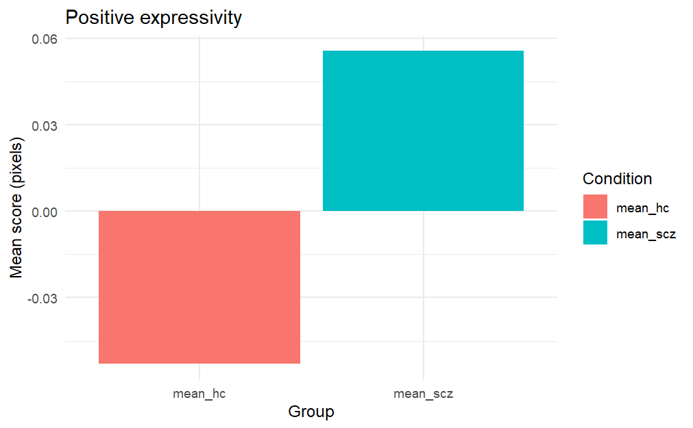

```r
## Step 1: dataset
mean_expressivity_pos = merge(data.frame(mean_expressivity_hc = result_hc$mean_expressivity),
                              data.frame(mean_expressivity_scz = result_scz$mean_expressivity),
                              by = "row.names", all = TRUE)
rownames(mean_expressivity_pos) = NULL
colnames(mean_expressivity_pos) = c("Index", "mean_expressivity_hc", "mean_expressivity_scz")

means = mean_expressivity_pos %>%
  summarise(
    mean_hc = mean(mean_expressivity_hc, na.rm = TRUE),
    mean_scz = mean(mean_expressivity_scz, na.rm = TRUE)
  )

means_long = pivot_longer(means, cols = everything(),
                          names_to = "Condition", values_to = "Mean")

## Step 2: barplot
bar_plot_pos = ggplot(means_long, aes(x = Condition, y = Mean, fill = Condition)) +
  geom_bar(stat = "identity", position = "dodge") +
  labs(title = "Positive expressivity",
       x = "Group",
       y = "Mean score (pixels)") +
  theme_minimal()

bar_plot_pos
```

```r
## Step 3: inferential statistics
hc_values = mean_expressivity_pos$mean_expressivity_hc
scz_values = mean_expressivity_pos$mean_expressivity_scz
hc_values_clean = na.omit(hc_values)
scz_values_clean = na.omit(scz_values)
shapiro_hc = shapiro.test(hc_values_clean)
shapiro_scz = shapiro.test(scz_values_clean)
levene_test = leveneTest(c(hc_values_clean, scz_values_clean),
                         factor(c(rep("HC", length(hc_values_clean)), rep("SCZ", length(scz_values_clean)))))
if (shapiro_hc$p.value > 0.05 && shapiro_scz$p.value > 0.05 && levene_test$`Pr(>F)`[1] > 0.05) {
  # Normality : test t de Student
  t_test_result_exp = t.test(hc_values_clean, scz_values_clean)
  print("Test t de Student:")
  print(t_test_result_exp)
} else {
  # else: test de Wilcoxon
  wilcox_test_exp = wilcox.test(hc_values_clean, scz_values_clean)
  print("Test de Wilcoxon:")
  print(wilcox_test_exp)
}
```

```
[1] "Test de Wilcoxon:"

    Wilcoxon rank sum exact test

data:  hc_values_clean and scz_values_clean
W = 179, p-value = 0.5831
alternative hypothesis: true location shift is not equal to 0
```

### 3.2. Single AU analysis

```
[1] "Test de Wilcoxon significatif pour mean_AU26_r :"

    Wilcoxon rank sum exact test

data:  hc_values and scz_values
W = 294, p-value = 0.01031
alternative hypothesis: true location shift is not equal to 0

[1] "Taille d'effet (r) : 0.359"
```

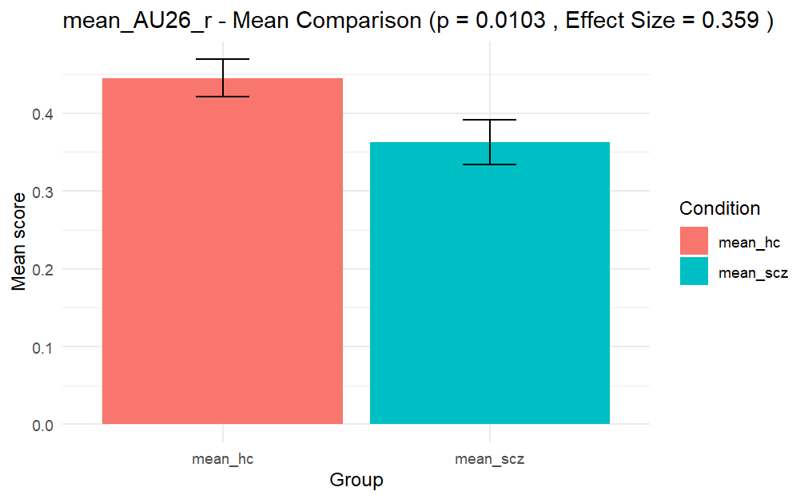

```r
cohen_d = function(x, y) {
  n1 = length(x)
  n2 = length(y)
  mean_diff = mean(x) - mean(y)
  pooled_sd = sqrt(((n1 - 1) * var(x) + (n2 - 1) * var(y)) / (n1 + n2 - 2))
  return(mean_diff / pooled_sd)
}

wilcoxon_r = function(stat, n) {
  return(stat / (n * (n + 1) / 2))
}

variables_au = c(
  "mean_AU01_r", "mean_AU02_r", "mean_AU04_r", "mean_AU05_r",
  "mean_AU06_r", "mean_AU07_r", "mean_AU09_r", "mean_AU10_r",
  "mean_AU12_r", "mean_AU14_r", "mean_AU15_r", "mean_AU17_r",
  "mean_AU20_r", "mean_AU23_r", "mean_AU25_r", "mean_AU26_r",
  "mean_AU45_r"
)

for (variable in variables_au) {
  # Step 1: dataset
  au_data = merge(
    data.frame(hc = result_hc[[variable]]),
    data.frame(scz = result_scz[[variable]]),
    by = "row.names", all = TRUE
  )
  rownames(au_data) = NULL
  colnames(au_data) = c("Index", "hc", "scz")

  means = au_data %>%
    summarise(
      mean_hc = mean(hc, na.rm = TRUE),
      mean_scz = mean(scz, na.rm = TRUE)
    )

  means_long = pivot_longer(means, cols = everything(),
                             names_to = "Condition", values_to = "Mean")

  # Step 2: t de Student or Wilcoxon
  hc_values = na.omit(au_data$hc)
  scz_values = na.omit(au_data$scz)
  shapiro_test_hc = shapiro.test(hc_values)
  shapiro_test_scz = shapiro.test(scz_values)
  levene_test = leveneTest(c(hc_values, scz_values),
                            factor(c(rep("HC", length(hc_values)), rep("SCZ", length(scz_values)))))

  is_significant = FALSE
  p_value = NA
  effect_size = NA

  if (shapiro_test_hc$p.value > 0.05 && shapiro_test_scz$p.value > 0.05 && levene_test$`Pr(>F)`[1] > 0.05) {
    # Test t de Student
    t_test_result = t.test(hc_values, scz_values)
    p_value = t_test_result$p.value
    if (p_value < 0.05) {
      is_significant = TRUE
      effect_size = cohen_d(hc_values, scz_values)
      print(paste("Test t de Student significatif pour", variable, ":"))
      print(t_test_result)
      print(paste("Taille d'effet (Cohen's d) :", round(effect_size, 3)))
    }
  } else {
    # Test de Wilcoxon
    wilcox_test_result = wilcox.test(hc_values, scz_values)
    p_value = wilcox_test_result$p.value
    if (p_value < 0.05) {
      is_significant = TRUE
      effect_size = wilcoxon_r(wilcox_test_result$statistic, length(hc_values) + length(scz_values))
      print(paste("Test de Wilcoxon significatif pour", variable, ":"))
      print(wilcox_test_result)
      print(paste("Taille d'effet (r) :", round(effect_size, 3)))
    }
  }

  # Step 3: barplot
  if (is_significant) {
    sem_hc = sd(hc_values, na.rm = TRUE) / sqrt(length(hc_values))
    sem_scz = sd(scz_values, na.rm = TRUE) / sqrt(length(scz_values))

    means_long = means_long %>%
      mutate(
        SEM = c(sem_hc, sem_scz)
      )

    bar_plot = ggplot(means_long, aes(x = Condition, y = Mean, fill = Condition)) +
      geom_bar(stat = "identity", position = "dodge") +
      geom_errorbar(aes(ymin = Mean - SEM, ymax = Mean + SEM),
                    width = 0.2, position = position_dodge(0.9)) +
      labs(title = paste(variable, "- Mean Comparison (p =", signif(p_value, 3),
                         ", Effect Size =", signif(effect_size, 3), ")"),
           x = "Group",
           y = "Mean score") +
      theme_minimal()

    print(bar_plot)
  }
}
```

## 4. Rater participants descriptive statistics

```r
all_participants = bind_rows(result_1st_imp, result_1st_imp_2, result_1st_imp_3)
unique_participants = all_participants %>% distinct(CASE, .keep_all = TRUE)

rater_participants_descriptive = unique_participants %>%
  summarise(
    Mean_age = mean(Age, na.rm = TRUE),
    Sd_age = sd(Age, na.rm = TRUE),
    Gender_H = sum(Gender == "H"),
    Gender_F = sum(Gender == "F")
  )

rater_participants_descriptive
```

| Mean_age | Sd_age | Gender_H | Gender_F |
| --- | --- | --- | --- |
| 30.60667 | 12.65381 | 101 | 199 |

```r
create_descriptive_table = function(data) {
  data %>%
    summarise(
      Mean_age = mean(Age, na.rm = TRUE),
      Sd_age = sd(Age, na.rm = TRUE),
      Gender_H = sum(Gender == "H"),
      Gender_F = sum(Gender == "F")
    )
}

descriptive_1st_imp = create_descriptive_table(result_1st_imp)
descriptive_1st_imp_2 = create_descriptive_table(result_1st_imp_2)
descriptive_1st_imp_3 = create_descriptive_table(result_1st_imp_3)

all_participants = bind_rows(
  result_1st_imp %>% mutate(Dataset = "1"),
  result_1st_imp_2 %>% mutate(Dataset = "2"),
  result_1st_imp_3 %>% mutate(Dataset = "3")
)

unique_participants = all_participants %>% distinct(CASE, .keep_all = TRUE)

rater_participants_descriptive = unique_participants %>%
  summarise(
    Mean_age = mean(Age, na.rm = TRUE),
    Sd_age = sd(Age, na.rm = TRUE),
    Gender_H = sum(Gender == "H"),
    Gender_F = sum(Gender == "F")
  )

unique_participants$Gender = as.factor(ifelse(unique_participants$Gender == "H", 1, 0))

lmm_age = lmer(Age ~ Dataset + (1 | Dataset), data = unique_participants)
summary(lmm_age)
```

```
Linear mixed model fit by REML. t-tests use Satterthwaite's method [
lmerModLmerTest]
Formula: Age ~ Dataset + (1 | Dataset)
   Data: unique_participants

REML criterion at convergence: 2334.3

Scaled residuals:
    Min      1Q  Median      3Q     Max
-1.5033 -0.7554 -0.3291  0.8383  3.0673

Random effects:
 Groups   Name        Variance Std.Dev.
 Dataset  (Intercept)  16.39    4.049
 Residual             144.80   12.033
Number of obs: 300, groups:  Dataset, 3

Fixed effects:
              Estimate Std. Error         df t value Pr(>|t|)
(Intercept)  3.277e+01  4.224e+00  1.245e-09   7.758        1
Dataset2     1.320e+00  5.974e+00  1.245e-09   0.221        1
Dataset3    -7.810e+00  5.974e+00  1.245e-09  -1.307        1

Correlation of Fixed Effects:
         (Intr) Datst2
Dataset2 -0.707
Dataset3 -0.707  0.500
optimizer (nloptwrap) convergence code: 0 (OK)
unable to evaluate scaled gradient
 Hessian is numerically singular: parameters are not uniquely determined
```

```r
anova_lmm_age_global = Anova(lmm_age, type = "III")
print(anova_lmm_age_global)
```

```
Analysis of Deviance Table (Type III Wald chisquare tests)

Response: Age
              Chisq Df Pr(>Chisq)
(Intercept) 60.1868  1  8.627e-15 ***
Dataset      2.7294  2     0.2555
---
Signif. codes:  0 ‘***’ 0.001 ‘**’ 0.01 ‘*’ 0.05 ‘.’ 0.1 ‘ ’ 1
```

```r
lmm_gender = glmer(Gender ~ Dataset + (1 | Dataset), data = unique_participants, family = binomial)
```

```
boundary (singular) fit: see help('isSingular')
```

```r
summary(lmm_gender)
```

```
Generalized linear mixed model fit by maximum likelihood (Laplace
  Approximation) [glmerMod]
 Family: binomial  ( logit )
Formula: Gender ~ Dataset + (1 | Dataset)
   Data: unique_participants

     AIC      BIC   logLik deviance df.resid
   386.9    401.7   -189.4    378.9      296

Scaled residuals:
    Min      1Q  Median      3Q     Max
-0.8336 -0.7018 -0.6082  1.1996  1.6443

Random effects:
 Groups  Name        Variance Std.Dev.
 Dataset (Intercept) 0        0
Number of obs: 300, groups:  Dataset, 3

Fixed effects:
            Estimate Std. Error z value Pr(>|z|)
(Intercept)  -0.7082     0.2127  -3.330 0.000868 ***
Dataset2      0.3442     0.2942   1.170 0.242027
Dataset3     -0.2864     0.3098  -0.925 0.355140
---
Signif. codes:  0 ‘***’ 0.001 ‘**’ 0.01 ‘*’ 0.05 ‘.’ 0.1 ‘ ’ 1

Correlation of Fixed Effects:
         (Intr) Datst2
Dataset2 -0.723
Dataset3 -0.687  0.496
optimizer (Nelder_Mead) convergence code: 0 (OK)
boundary (singular) fit: see help('isSingular')
```

```r
anova_lmm_gender_global = Anova(lmm_gender, type = "III")
print(anova_lmm_gender_global)
```

```
Analysis of Deviance Table (Type III Wald chisquare tests)

Response: Gender
              Chisq Df Pr(>Chisq)
(Intercept) 11.0891  1  0.0008684 ***
Dataset      4.3745  2  0.1122257
---
Signif. codes:  0 ‘***’ 0.001 ‘**’ 0.01 ‘*’ 0.05 ‘.’ 0.1 ‘ ’ 1
```

## 5. 1st imp

### 5.1 Analyze items by items

#### 5.1.1 Descriptive statistics

Dataset 1 - no label

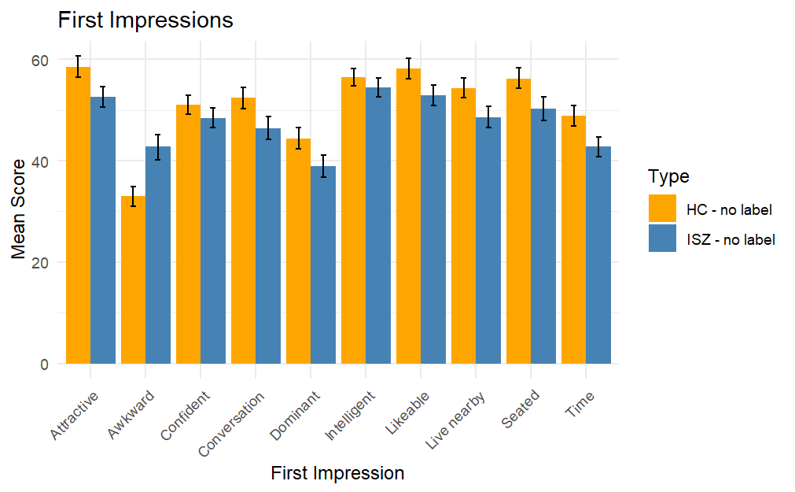

```r
impressions_long = result_1st_imp %>%
  pivot_longer(
    cols = c(Sympathique, Bizarre, Intelligente, Appreciable, Confiance, Dominante, Conversation, Temps, Voisin, Assis),
    names_to = "Impression",
    values_to = "Score"
  ) %>%
  mutate(Impression = case_when(
    Impression == "Sympathique" ~ "Attractive",
    Impression == "Bizarre" ~ "Awkward",
    Impression == "Intelligente" ~ "Intelligent",
    Impression == "Appreciable" ~ "Likeable",
    Impression == "Confiance" ~ "Confident",
    Impression == "Dominante" ~ "Dominant",
    Impression == "Conversation" ~ "Conversation",
    Impression == "Temps" ~ "Time",
    Impression == "Voisin" ~ "Live nearby",
    Impression == "Assis" ~ "Seated",
    TRUE ~ Impression
  ))

ggplot(impressions_long, aes(x = Impression, y = Score, fill = Type)) +
  stat_summary(fun = mean, geom = "bar", position = "dodge") +
  stat_summary(fun.data = mean_cl_boot, geom = "errorbar", position = position_dodge(0.9), width = 0.2) +
  theme_minimal() +
  labs(title = "First Impressions",
       x = "First Impression",
       y = "Mean Score") +
  scale_fill_manual(
    values = c("Patient" = "steelblue", "Healthy" = "orange"),
    labels = c("Patient" = "ISZ - no label", "Healthy" = "HC - no label")
  ) +
  theme(axis.text.x = element_text(angle = 45, hjust = 1))
```

Dataset 2 - SCZ label

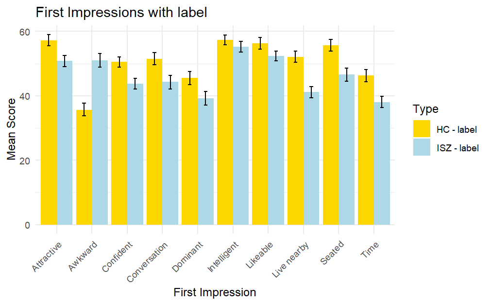

```r
impressions_long_2 = result_1st_imp_2 %>%
  pivot_longer(
    cols = c(Sympathique, Bizarre, Intelligente, Appreciable, Confiance, Dominante, Conversation, Temps, Voisin, Assis),
    names_to = "Impression",
    values_to = "Score"
  ) %>%
  mutate(Impression = case_when(
    Impression == "Sympathique" ~ "Attractive",
    Impression == "Bizarre" ~ "Awkward",
    Impression == "Intelligente" ~ "Intelligent",
    Impression == "Appreciable" ~ "Likeable",
    Impression == "Confiance" ~ "Confident",
    Impression == "Dominante" ~ "Dominant",
    Impression == "Conversation" ~ "Conversation",
    Impression == "Temps" ~ "Time",
    Impression == "Voisin" ~ "Live nearby",
    Impression == "Assis" ~ "Seated",
    TRUE ~ Impression
  ))

ggplot(impressions_long_2, aes(x = Impression, y = Score, fill = Type)) +
  stat_summary(fun = mean, geom = "bar", position = "dodge") +
  stat_summary(fun.data = mean_cl_boot, geom = "errorbar", position = position_dodge(0.9), width = 0.2) +
  theme_minimal() +
  labs(title = "First Impressions with label",
       x = "First Impression",
       y = "Mean Score") +
  scale_fill_manual(
    values = c("Patient" = "lightblue", "Healthy" = "gold"),
    labels = c("Patient" = "ISZ - label", "Healthy" = "HC - label")
  ) +
  theme(axis.text.x = element_text(angle = 45, hjust = 1))
```

Dataset 3 - ASD label instead of SCZ

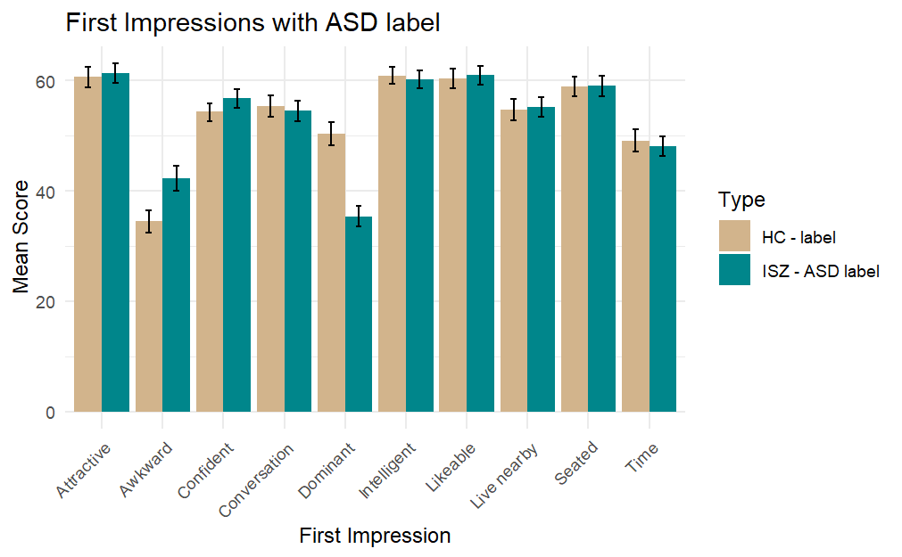

```r
impressions_long_3 = result_1st_imp_3 %>%
  pivot_longer(
    cols = c(Sympathique, Bizarre, Intelligente, Appreciable, Confiance, Dominante, Conversation, Temps, Voisin, Assis),
    names_to = "Impression",
    values_to = "Score"
  ) %>%
  mutate(Impression = case_when(
    Impression == "Sympathique" ~ "Attractive",
    Impression == "Bizarre" ~ "Awkward",
    Impression == "Intelligente" ~ "Intelligent",
    Impression == "Appreciable" ~ "Likeable",
    Impression == "Confiance" ~ "Confident",
    Impression == "Dominante" ~ "Dominant",
    Impression == "Conversation" ~ "Conversation",
    Impression == "Temps" ~ "Time",
    Impression == "Voisin" ~ "Live nearby",
    Impression == "Assis" ~ "Seated",
    TRUE ~ Impression
  ))

ggplot(impressions_long_3, aes(x = Impression, y = Score, fill = Type)) +
  stat_summary(fun = mean, geom = "bar", position = "dodge") +
  stat_summary(fun.data = mean_cl_boot, geom = "errorbar", position = position_dodge(0.9), width = 0.2) +
  theme_minimal() +
  labs(title = "First Impressions with ASD label",
       x = "First Impression",
       y = "Mean Score") +
  scale_fill_manual(
    values = c("Patient" = "turquoise4", "Healthy" = "tan"),
    labels = c("Patient" = "ISZ - ASD label", "Healthy" = "HC - label")
  ) +
  theme(axis.text.x = element_text(angle = 45, hjust = 1))
```

Combined of every dataset

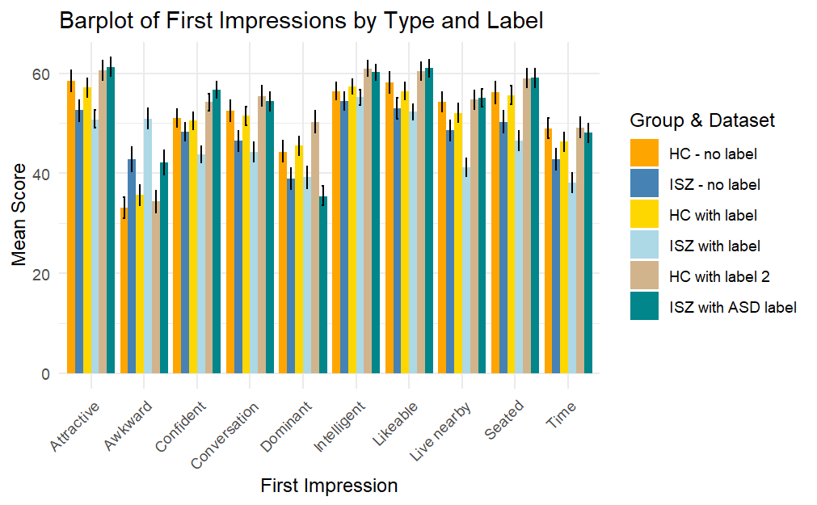

```r
impressions_long$Dataset = "Dataset_1"
impressions_long_2$Dataset = "Dataset_2"
impressions_long_3$Dataset = "Dataset_3"
combined_impressions = bind_rows(impressions_long, impressions_long_2, impressions_long_3)


ggplot(combined_impressions, aes(x = Impression, y = Score, fill = interaction(Type, Dataset))) +
  stat_summary(fun = mean, geom = "bar", position = position_dodge(width = 0.9)) +
  stat_summary(fun.data = mean_cl_boot, geom = "errorbar", position = position_dodge(width = 0.9), width = 0.2) +
  theme_minimal() +
  labs(
    title = "Barplot of First Impressions by Type and Label",
    x = "First Impression",
    y = "Mean Score"
  ) +
  scale_fill_manual(
    values = c(
      "Patient.Dataset_1" = "steelblue",
      "Healthy.Dataset_1" = "orange",
      "Healthy.Dataset_2" = "gold",
      "Patient.Dataset_2" = "lightblue",
      "Healthy.Dataset_3" = "tan",
      "Patient.Dataset_3" = "turquoise4"
    ),
    labels = c(
      "HC - no label",
      "ISZ - no label",
      "HC with label",
      "ISZ with label",
      "HC with label 2",
      "ISZ with ASD label"
    ),
    name = "Group & Dataset"
  ) +
  theme(axis.text.x = element_text(angle = 45, hjust = 1))
```

#### 5.1.2 Inferential statistics

```r
attributes = c("Attractive", "Intelligent", "Awkward", "Confident", "Dominant", "Conversation", "Time", "Live Nearby", "Seated")
post_hoc_results = list()

combined_impressions$Type = factor(combined_impressions$Type)
combined_impressions$Dataset = factor(combined_impressions$Dataset)
combined_impressions$Impression = factor(combined_impressions$Impression)

for (attr in attributes) {
  filtered_data = combined_impressions[combined_impressions$Impression == attr, ]
  if (nrow(filtered_data) > 0) {
    model_attr = lmerTest::lmer(Score ~ interaction(Type, Dataset, Impression) + (1|CASE), data = filtered_data)
    cat("Model summary for attribute:", attr, "\n")
    print(summary(model_attr))
    cat("\n")
    emmeans_result = emmeans(model_attr, ~ interaction(Type, Dataset, Impression), adjust = "Tukey", CIs = TRUE,
                              pbkrtest.limit = 4800, lmerTest.limit = 4800, lmer.df = "satterthwaite")
    post_hoc_comparisons = pairs(emmeans_result)
    ci_post_hoc = confint(post_hoc_comparisons)

    model_attr_df = as.data.frame(post_hoc_comparisons)
    ci_attr_df = as.data.frame(ci_post_hoc)

    model_attr_df$CI_lower = ci_attr_df$lower.CL
    model_attr_df$CI_upper = ci_attr_df$upper.CL

    sigma_residual_attr = car::sigmaHat(model_attr)
    model_attr_df$d = model_attr_df$estimate / sigma_residual_attr

    post_hoc_results[[attr]] = model_attr_df
  } else {
    cat("No data for attribute:", attr, "\n")
  }
}
```

```
Model summary for attribute: Attractive
Linear mixed model fit by REML. t-tests use Satterthwaite's method [
lmerModLmerTest]
Formula: Score ~ interaction(Type, Dataset, Impression) + (1 | CASE)
   Data: filtered_data

REML criterion at convergence: 26643.8

Scaled residuals:
    Min      1Q  Median      3Q     Max
-3.7582 -0.5660  0.0039  0.6203  3.0811

Random effects:
 Groups   Name        Variance Std.Dev.
 CASE     (Intercept)  91       9.54
 Residual             376      19.39
Number of obs: 2999, groups:  CASE, 300

Fixed effects:
                                                                   Estimate
(Intercept)                                                          58.504
interaction(Type, Dataset, Impression)Patient.Dataset_1.Attractive   -5.888
interaction(Type, Dataset, Impression)Healthy.Dataset_2.Attractive   -1.249
interaction(Type, Dataset, Impression)Patient.Dataset_2.Attractive   -7.730
interaction(Type, Dataset, Impression)Healthy.Dataset_3.Attractive    2.134
interaction(Type, Dataset, Impression)Patient.Dataset_3.Attractive    2.808
                                                                   Std. Error
(Intercept)                                                             1.289
interaction(Type, Dataset, Impression)Patient.Dataset_1.Attractive      1.226
interaction(Type, Dataset, Impression)Healthy.Dataset_2.Attractive      1.824
interaction(Type, Dataset, Impression)Patient.Dataset_2.Attractive      1.823
interaction(Type, Dataset, Impression)Healthy.Dataset_3.Attractive      1.823
interaction(Type, Dataset, Impression)Patient.Dataset_3.Attractive      1.823
                                                                         df
(Intercept)                                                         491.442
interaction(Type, Dataset, Impression)Patient.Dataset_1.Attractive 2696.060
interaction(Type, Dataset, Impression)Healthy.Dataset_2.Attractive  491.883
interaction(Type, Dataset, Impression)Patient.Dataset_2.Attractive  491.442
interaction(Type, Dataset, Impression)Healthy.Dataset_3.Attractive  491.442
interaction(Type, Dataset, Impression)Patient.Dataset_3.Attractive  491.442
```

[output cut: 22 more lines]

```
Signif. codes:  0 ‘***’ 0.001 ‘**’ 0.01 ‘*’ 0.05 ‘.’ 0.1 ‘ ’ 1

Correlation of Fixed Effects:
              (Intr) i(T,D,I)P.D_1 i(T,D,I)H.D_2 i(T,D,I)P.D_2
i(T,D,I)P.D_1 -0.476
i(T,D,I)H.D_2 -0.707  0.336
i(T,D,I)P.D_2 -0.707  0.336         0.774
i(T,D,I)H.D_3 -0.707  0.336         0.500         0.500
i(T,D,I)P.D_3 -0.707  0.336         0.500         0.500
              i(T,D,I)H.D_3
i(T,D,I)P.D_1
i(T,D,I)H.D_2
i(T,D,I)P.D_2
i(T,D,I)H.D_3
i(T,D,I)P.D_3  0.774
```

```
Model summary for attribute: Intelligent
Linear mixed model fit by REML. t-tests use Satterthwaite's method [
lmerModLmerTest]
Formula: Score ~ interaction(Type, Dataset, Impression) + (1 | CASE)
   Data: filtered_data

REML criterion at convergence: 25375.7

Scaled residuals:
    Min      1Q  Median      3Q     Max
-4.2673 -0.4487 -0.0258  0.5007  3.3946

Random effects:
 Groups   Name        Variance Std.Dev.
 CASE     (Intercept) 116.6    10.80
 Residual             232.8    15.26
Number of obs: 2999, groups:  CASE, 300

Fixed effects:
                                                                    Estimate
(Intercept)                                                           56.456
interaction(Type, Dataset, Impression)Patient.Dataset_1.Intelligent   -2.056
interaction(Type, Dataset, Impression)Healthy.Dataset_2.Intelligent    0.922
interaction(Type, Dataset, Impression)Patient.Dataset_2.Intelligent   -1.274
interaction(Type, Dataset, Impression)Healthy.Dataset_3.Intelligent    4.460
interaction(Type, Dataset, Impression)Patient.Dataset_3.Intelligent    3.808
                                                                    Std. Error
(Intercept)                                                              1.277
interaction(Type, Dataset, Impression)Patient.Dataset_1.Intelligent      0.965
interaction(Type, Dataset, Impression)Healthy.Dataset_2.Intelligent      1.807
interaction(Type, Dataset, Impression)Patient.Dataset_2.Intelligent      1.806
interaction(Type, Dataset, Impression)Healthy.Dataset_3.Intelligent      1.806
interaction(Type, Dataset, Impression)Patient.Dataset_3.Intelligent      1.806
                                                                          df
(Intercept)                                                          402.841
interaction(Type, Dataset, Impression)Patient.Dataset_1.Intelligent 2696.034
interaction(Type, Dataset, Impression)Healthy.Dataset_2.Intelligent  403.082
interaction(Type, Dataset, Impression)Patient.Dataset_2.Intelligent  402.841
interaction(Type, Dataset, Impression)Healthy.Dataset_3.Intelligent  402.841
interaction(Type, Dataset, Impression)Patient.Dataset_3.Intelligent  402.841
```

[output cut: 22 more lines]

```
Signif. codes:  0 ‘***’ 0.001 ‘**’ 0.01 ‘*’ 0.05 ‘.’ 0.1 ‘ ’ 1

Correlation of Fixed Effects:
              (Intr) i(T,D,I)P.D_1 i(T,D,I)H.D_2 i(T,D,I)P.D_2
i(T,D,I)P.D_1 -0.378
i(T,D,I)H.D_2 -0.707  0.267
i(T,D,I)P.D_2 -0.707  0.267         0.857
i(T,D,I)H.D_3 -0.707  0.267         0.500         0.500
i(T,D,I)P.D_3 -0.707  0.267         0.500         0.500
              i(T,D,I)H.D_3
i(T,D,I)P.D_1
i(T,D,I)H.D_2
i(T,D,I)P.D_2
i(T,D,I)H.D_3
i(T,D,I)P.D_3  0.857
```

```
Model summary for attribute: Awkward
Linear mixed model fit by REML. t-tests use Satterthwaite's method [
lmerModLmerTest]
Formula: Score ~ interaction(Type, Dataset, Impression) + (1 | CASE)
   Data: filtered_data

REML criterion at convergence: 27436

Scaled residuals:
    Min      1Q  Median      3Q     Max
-2.6191 -0.6841 -0.1118  0.6298  3.7235

Random effects:
 Groups   Name        Variance Std.Dev.
 CASE     (Intercept) 128.5    11.34
 Residual             487.0    22.07
Number of obs: 2999, groups:  CASE, 300

Fixed effects:
                                                                Estimate
(Intercept)                                                       33.030
interaction(Type, Dataset, Impression)Patient.Dataset_1.Awkward    9.734
interaction(Type, Dataset, Impression)Healthy.Dataset_2.Awkward    2.604
interaction(Type, Dataset, Impression)Patient.Dataset_2.Awkward   17.912
interaction(Type, Dataset, Impression)Healthy.Dataset_3.Awkward    1.414
interaction(Type, Dataset, Impression)Patient.Dataset_3.Awkward    9.186
                                                                Std. Error
(Intercept)                                                          1.503
interaction(Type, Dataset, Impression)Patient.Dataset_1.Awkward      1.396
interaction(Type, Dataset, Impression)Healthy.Dataset_2.Awkward      2.126
interaction(Type, Dataset, Impression)Patient.Dataset_2.Awkward      2.126
interaction(Type, Dataset, Impression)Healthy.Dataset_3.Awkward      2.126
interaction(Type, Dataset, Impression)Patient.Dataset_3.Awkward      2.126
                                                                      df
(Intercept)                                                      478.679
interaction(Type, Dataset, Impression)Patient.Dataset_1.Awkward 2696.050
interaction(Type, Dataset, Impression)Healthy.Dataset_2.Awkward  479.092
interaction(Type, Dataset, Impression)Patient.Dataset_2.Awkward  478.679
interaction(Type, Dataset, Impression)Healthy.Dataset_3.Awkward  478.679
interaction(Type, Dataset, Impression)Patient.Dataset_3.Awkward  478.679
```

[output cut: 22 more lines]

```
Signif. codes:  0 ‘***’ 0.001 ‘**’ 0.01 ‘*’ 0.05 ‘.’ 0.1 ‘ ’ 1

Correlation of Fixed Effects:
              (Intr) i(T,D,I)P.D_1 i(T,D,I)H.D_2 i(T,D,I)P.D_2
i(T,D,I)P.D_1 -0.464
i(T,D,I)H.D_2 -0.707  0.328
i(T,D,I)P.D_2 -0.707  0.328         0.784
i(T,D,I)H.D_3 -0.707  0.328         0.500         0.500
i(T,D,I)P.D_3 -0.707  0.328         0.500         0.500
              i(T,D,I)H.D_3
i(T,D,I)P.D_1
i(T,D,I)H.D_2
i(T,D,I)P.D_2
i(T,D,I)H.D_3
i(T,D,I)P.D_3  0.784
```

```
Model summary for attribute: Confident
Linear mixed model fit by REML. t-tests use Satterthwaite's method [
lmerModLmerTest]
Formula: Score ~ interaction(Type, Dataset, Impression) + (1 | CASE)
   Data: filtered_data

REML criterion at convergence: 26125.7

Scaled residuals:
    Min      1Q  Median      3Q     Max
-3.6312 -0.5352  0.0078  0.5349  3.3075

Random effects:
 Groups   Name        Variance Std.Dev.
 CASE     (Intercept)  89.51    9.461
 Residual             312.46   17.677
Number of obs: 2999, groups:  CASE, 300

Fixed effects:
                                                                   Estimate
(Intercept)                                                         51.0860
interaction(Type, Dataset, Impression)Patient.Dataset_1.Confident   -2.7680
interaction(Type, Dataset, Impression)Healthy.Dataset_2.Confident   -0.5955
interaction(Type, Dataset, Impression)Patient.Dataset_2.Confident   -7.2940
interaction(Type, Dataset, Impression)Healthy.Dataset_3.Confident    3.2260
interaction(Type, Dataset, Impression)Patient.Dataset_3.Confident    5.6800
                                                                  Std. Error
(Intercept)                                                           1.2329
interaction(Type, Dataset, Impression)Patient.Dataset_1.Confident     1.1180
interaction(Type, Dataset, Impression)Healthy.Dataset_2.Confident     1.7440
interaction(Type, Dataset, Impression)Patient.Dataset_2.Confident     1.7436
interaction(Type, Dataset, Impression)Healthy.Dataset_3.Confident     1.7436
interaction(Type, Dataset, Impression)Patient.Dataset_3.Confident     1.7436
                                                                         df
(Intercept)                                                        467.1279
interaction(Type, Dataset, Impression)Patient.Dataset_1.Confident 2696.0520
interaction(Type, Dataset, Impression)Healthy.Dataset_2.Confident  467.5146
interaction(Type, Dataset, Impression)Patient.Dataset_2.Confident  467.1279
interaction(Type, Dataset, Impression)Healthy.Dataset_3.Confident  467.1279
interaction(Type, Dataset, Impression)Patient.Dataset_3.Confident  467.1279
```

[output cut: 22 more lines]

```
Signif. codes:  0 ‘***’ 0.001 ‘**’ 0.01 ‘*’ 0.05 ‘.’ 0.1 ‘ ’ 1

Correlation of Fixed Effects:
              (Intr) i(T,D,I)P.D_1 i(T,D,I)H.D_2 i(T,D,I)P.D_2
i(T,D,I)P.D_1 -0.453
i(T,D,I)H.D_2 -0.707  0.321
i(T,D,I)P.D_2 -0.707  0.321         0.794
i(T,D,I)H.D_3 -0.707  0.321         0.500         0.500
i(T,D,I)P.D_3 -0.707  0.321         0.500         0.500
              i(T,D,I)H.D_3
i(T,D,I)P.D_1
i(T,D,I)H.D_2
i(T,D,I)P.D_2
i(T,D,I)H.D_3
i(T,D,I)P.D_3  0.794
```

```
Model summary for attribute: Dominant
Linear mixed model fit by REML. t-tests use Satterthwaite's method [
lmerModLmerTest]
Formula: Score ~ interaction(Type, Dataset, Impression) + (1 | CASE)
   Data: filtered_data

REML criterion at convergence: 27338.4

Scaled residuals:
     Min       1Q   Median       3Q      Max
-2.68582 -0.68634 -0.05721  0.58086  3.10417

Random effects:
 Groups   Name        Variance Std.Dev.
 CASE     (Intercept)  91.15    9.547
 Residual             482.26   21.960
Number of obs: 2999, groups:  CASE, 300

Fixed effects:
                                                                 Estimate
(Intercept)                                                        44.328
interaction(Type, Dataset, Impression)Patient.Dataset_1.Dominant   -5.328
interaction(Type, Dataset, Impression)Healthy.Dataset_2.Dominant    1.227
interaction(Type, Dataset, Impression)Patient.Dataset_2.Dominant   -5.090
interaction(Type, Dataset, Impression)Healthy.Dataset_3.Dominant    5.990
interaction(Type, Dataset, Impression)Patient.Dataset_3.Dominant   -8.928
                                                                 Std. Error
(Intercept)                                                           1.370
interaction(Type, Dataset, Impression)Patient.Dataset_1.Dominant      1.389
interaction(Type, Dataset, Impression)Healthy.Dataset_2.Dominant      1.938
interaction(Type, Dataset, Impression)Patient.Dataset_2.Dominant      1.937
interaction(Type, Dataset, Impression)Healthy.Dataset_3.Dominant      1.937
interaction(Type, Dataset, Impression)Patient.Dataset_3.Dominant      1.937
                                                                       df
(Intercept)                                                       531.075
interaction(Type, Dataset, Impression)Patient.Dataset_1.Dominant 2696.067
interaction(Type, Dataset, Impression)Healthy.Dataset_2.Dominant  531.603
interaction(Type, Dataset, Impression)Patient.Dataset_2.Dominant  531.075
interaction(Type, Dataset, Impression)Healthy.Dataset_3.Dominant  531.075
interaction(Type, Dataset, Impression)Patient.Dataset_3.Dominant  531.075
```

[output cut: 22 more lines]

```
Signif. codes:  0 ‘***’ 0.001 ‘**’ 0.01 ‘*’ 0.05 ‘.’ 0.1 ‘ ’ 1

Correlation of Fixed Effects:
              (Intr) i(T,D,I)P.D_1 i(T,D,I)H.D_2 i(T,D,I)P.D_2
i(T,D,I)P.D_1 -0.507
i(T,D,I)H.D_2 -0.707  0.358
i(T,D,I)P.D_2 -0.707  0.359         0.743
i(T,D,I)H.D_3 -0.707  0.359         0.500         0.500
i(T,D,I)P.D_3 -0.707  0.359         0.500         0.500
              i(T,D,I)H.D_3
i(T,D,I)P.D_1
i(T,D,I)H.D_2
i(T,D,I)P.D_2
i(T,D,I)H.D_3
i(T,D,I)P.D_3  0.743
```

```
Model summary for attribute: Conversation
Linear mixed model fit by REML. t-tests use Satterthwaite's method [
lmerModLmerTest]
Formula: Score ~ interaction(Type, Dataset, Impression) + (1 | CASE)
   Data: filtered_data

REML criterion at convergence: 26807.8

Scaled residuals:
    Min      1Q  Median      3Q     Max
-3.6841 -0.6268  0.0364  0.6366  3.1759

Random effects:
 Groups   Name        Variance Std.Dev.
 CASE     (Intercept) 130.7    11.43
 Residual             387.7    19.69
Number of obs: 2999, groups:  CASE, 300

Fixed effects:
                                                                      Estimate
(Intercept)                                                            52.4360
interaction(Type, Dataset, Impression)Patient.Dataset_1.Conversation   -5.9920
interaction(Type, Dataset, Impression)Healthy.Dataset_2.Conversation   -0.9179
interaction(Type, Dataset, Impression)Patient.Dataset_2.Conversation   -8.1180
interaction(Type, Dataset, Impression)Healthy.Dataset_3.Conversation    2.9940
interaction(Type, Dataset, Impression)Patient.Dataset_3.Conversation    2.0500
                                                                     Std. Error
(Intercept)                                                              1.4430
interaction(Type, Dataset, Impression)Patient.Dataset_1.Conversation     1.2453
interaction(Type, Dataset, Impression)Healthy.Dataset_2.Conversation     2.0411
interaction(Type, Dataset, Impression)Patient.Dataset_2.Conversation     2.0407
interaction(Type, Dataset, Impression)Healthy.Dataset_3.Conversation     2.0407
interaction(Type, Dataset, Impression)Patient.Dataset_3.Conversation     2.0407
                                                                            df
(Intercept)                                                           445.8542
interaction(Type, Dataset, Impression)Patient.Dataset_1.Conversation 2696.0384
interaction(Type, Dataset, Impression)Healthy.Dataset_2.Conversation  446.1929
interaction(Type, Dataset, Impression)Patient.Dataset_2.Conversation  445.8542
interaction(Type, Dataset, Impression)Healthy.Dataset_3.Conversation  445.8542
interaction(Type, Dataset, Impression)Patient.Dataset_3.Conversation  445.8542
```

[output cut: 22 more lines]

```
Signif. codes:  0 ‘***’ 0.001 ‘**’ 0.01 ‘*’ 0.05 ‘.’ 0.1 ‘ ’ 1

Correlation of Fixed Effects:
              (Intr) i(T,D,I)P.D_1 i(T,D,I)H.D_2 i(T,D,I)P.D_2
i(T,D,I)P.D_1 -0.431
i(T,D,I)H.D_2 -0.707  0.305
i(T,D,I)P.D_2 -0.707  0.305         0.814
i(T,D,I)H.D_3 -0.707  0.305         0.500         0.500
i(T,D,I)P.D_3 -0.707  0.305         0.500         0.500
              i(T,D,I)H.D_3
i(T,D,I)P.D_1
i(T,D,I)H.D_2
i(T,D,I)P.D_2
i(T,D,I)H.D_3
i(T,D,I)P.D_3  0.814
```

```
Model summary for attribute: Time
Linear mixed model fit by REML. t-tests use Satterthwaite's method [
lmerModLmerTest]
Formula: Score ~ interaction(Type, Dataset, Impression) + (1 | CASE)
   Data: filtered_data

REML criterion at convergence: 26606.1

Scaled residuals:
    Min      1Q  Median      3Q     Max
-2.8440 -0.5917 -0.0034  0.5768  3.6999

Random effects:
 Groups   Name        Variance Std.Dev.
 CASE     (Intercept) 125.0    11.18
 Residual             361.7    19.02
Number of obs: 2999, groups:  CASE, 300

Fixed effects:
                                                             Estimate
(Intercept)                                                    48.928
interaction(Type, Dataset, Impression)Patient.Dataset_1.Time   -6.154
interaction(Type, Dataset, Impression)Healthy.Dataset_2.Time   -2.619
interaction(Type, Dataset, Impression)Patient.Dataset_2.Time  -10.858
interaction(Type, Dataset, Impression)Healthy.Dataset_3.Time    0.138
interaction(Type, Dataset, Impression)Patient.Dataset_3.Time   -0.834
                                                             Std. Error
(Intercept)                                                       1.405
interaction(Type, Dataset, Impression)Patient.Dataset_1.Time      1.203
interaction(Type, Dataset, Impression)Healthy.Dataset_2.Time      1.987
interaction(Type, Dataset, Impression)Patient.Dataset_2.Time      1.987
interaction(Type, Dataset, Impression)Healthy.Dataset_3.Time      1.987
interaction(Type, Dataset, Impression)Patient.Dataset_3.Time      1.987
                                                                   df
(Intercept)                                                   442.798
interaction(Type, Dataset, Impression)Patient.Dataset_1.Time 2696.028
interaction(Type, Dataset, Impression)Healthy.Dataset_2.Time  443.130
interaction(Type, Dataset, Impression)Patient.Dataset_2.Time  442.798
interaction(Type, Dataset, Impression)Healthy.Dataset_3.Time  442.798
interaction(Type, Dataset, Impression)Patient.Dataset_3.Time  442.798
```

[output cut: 22 more lines]

```
Signif. codes:  0 ‘***’ 0.001 ‘**’ 0.01 ‘*’ 0.05 ‘.’ 0.1 ‘ ’ 1

Correlation of Fixed Effects:
              (Intr) i(T,D,I)P.D_1 i(T,D,I)H.D_2 i(T,D,I)P.D_2
i(T,D,I)P.D_1 -0.428
i(T,D,I)H.D_2 -0.707  0.303
i(T,D,I)P.D_2 -0.707  0.303         0.817
i(T,D,I)H.D_3 -0.707  0.303         0.500         0.500
i(T,D,I)P.D_3 -0.707  0.303         0.500         0.500
              i(T,D,I)H.D_3
i(T,D,I)P.D_1
i(T,D,I)H.D_2
i(T,D,I)P.D_2
i(T,D,I)H.D_3
i(T,D,I)P.D_3  0.817
```

```
No data for attribute: Live Nearby
Model summary for attribute: Seated
Linear mixed model fit by REML. t-tests use Satterthwaite's method [
lmerModLmerTest]
Formula: Score ~ interaction(Type, Dataset, Impression) + (1 | CASE)
   Data: filtered_data

REML criterion at convergence: 26695.2

Scaled residuals:
    Min      1Q  Median      3Q     Max
-3.1098 -0.5393  0.0481  0.6042  4.0582

Random effects:
 Groups   Name        Variance Std.Dev.
 CASE     (Intercept) 139.0    11.79
 Residual             370.3    19.24
Number of obs: 2999, groups:  CASE, 300

Fixed effects:
                                                                Estimate
(Intercept)                                                      56.1780
interaction(Type, Dataset, Impression)Patient.Dataset_1.Seated   -5.8980
interaction(Type, Dataset, Impression)Healthy.Dataset_2.Seated   -0.5576
interaction(Type, Dataset, Impression)Patient.Dataset_2.Seated   -9.6080
interaction(Type, Dataset, Impression)Healthy.Dataset_3.Seated    2.7380
interaction(Type, Dataset, Impression)Patient.Dataset_3.Seated    2.9120
                                                               Std. Error
(Intercept)                                                        1.4596
interaction(Type, Dataset, Impression)Patient.Dataset_1.Seated     1.2170
interaction(Type, Dataset, Impression)Healthy.Dataset_2.Seated     2.0645
interaction(Type, Dataset, Impression)Patient.Dataset_2.Seated     2.0642
interaction(Type, Dataset, Impression)Healthy.Dataset_3.Seated     2.0642
interaction(Type, Dataset, Impression)Patient.Dataset_3.Seated     2.0642
                                                                      df
(Intercept)                                                     432.9772
interaction(Type, Dataset, Impression)Patient.Dataset_1.Seated 2696.0360
interaction(Type, Dataset, Impression)Healthy.Dataset_2.Seated  433.2867
interaction(Type, Dataset, Impression)Patient.Dataset_2.Seated  432.9772
interaction(Type, Dataset, Impression)Healthy.Dataset_3.Seated  432.9772
```

[output cut: 23 more lines]

```
Signif. codes:  0 ‘***’ 0.001 ‘**’ 0.01 ‘*’ 0.05 ‘.’ 0.1 ‘ ’ 1

Correlation of Fixed Effects:
              (Intr) i(T,D,I)P.D_1 i(T,D,I)H.D_2 i(T,D,I)P.D_2
i(T,D,I)P.D_1 -0.417
i(T,D,I)H.D_2 -0.707  0.295
i(T,D,I)P.D_2 -0.707  0.295         0.826
i(T,D,I)H.D_3 -0.707  0.295         0.500         0.500
i(T,D,I)P.D_3 -0.707  0.295         0.500         0.500
              i(T,D,I)H.D_3
i(T,D,I)P.D_1
i(T,D,I)H.D_2
i(T,D,I)P.D_2
i(T,D,I)H.D_3
i(T,D,I)P.D_3  0.826
```

```r
for (attr in attributes) {
  cat("Post-hoc comparisons for attribute:", attr, "\n")

  if (!is.null(post_hoc_results[[attr]])) {
    result_attr_df = post_hoc_results[[attr]]
    result_attr_df_final = result_attr_df[, c("contrast", "estimate", "p.value", "CI_lower", "CI_upper", "d")]

    print(result_attr_df_final)
    cat("\n")
  } else {
    cat("No results for attribute:", attr, "\n")
  }
}
```

```
Post-hoc comparisons for attribute: Attractive
```

|  | contrast | estimate | p.value | CI_lower | CI_upper | d |
| --- | --- | --- | --- | --- | --- | --- |
| 1 | Healthy Dataset_1 Attractive - Patient Dataset_1 Attractive | 5.888000 | 2.458263e-05 | 2.390444 | 9.3855555 | 0.30363106 |
| 2 | Healthy Dataset_1 Attractive - Healthy Dataset_2 Attractive | 1.249454 | 9.835608e-01 | -3.968136 | 6.4670431 | 0.06443155 |
| 3 | Healthy Dataset_1 Attractive - Patient Dataset_2 Attractive | 7.730000 | 3.829536e-04 | 2.513664 | 12.9463362 | 0.39861891 |
| 4 | Healthy Dataset_1 Attractive - Healthy Dataset_3 Attractive | -2.134000 | 8.507766e-01 | -7.350336 | 3.0823362 | -0.11004563 |
| 5 | Healthy Dataset_1 Attractive - Patient Dataset_3 Attractive | -2.808000 | 6.384256e-01 | -8.024336 | 2.4083362 | -0.14480231 |
| 6 | Patient Dataset_1 Attractive - Healthy Dataset_2 Attractive | -4.638546 | 1.137272e-01 | -9.856136 | 0.5790431 | -0.23919951 |
| 7 | Patient Dataset_1 Attractive - Patient Dataset_2 Attractive | 1.842000 | 9.144693e-01 | -3.374336 | 7.0583362 | 0.09498784 |
| 8 | Patient Dataset_1 Attractive - Healthy Dataset_3 Attractive | -8.022000 | 1.922143e-04 | -13.238336 | -2.8056638 | -0.41367670 |
| 9 | Patient Dataset_1 Attractive - Patient Dataset_3 Attractive | -8.696000 | 3.580963e-05 | -13.912336 | -3.4796638 | -0.44843338 |
| 10 | Healthy Dataset_2 Attractive - Patient Dataset_2 Attractive | 6.480546 | 2.063995e-06 | 2.981107 | 9.9799857 | 0.33418736 |

[output cut: 5 more lines]

```
Post-hoc comparisons for attribute: Intelligent
```

|  | contrast | estimate | p.value | CI_lower | CI_upper | d |
| --- | --- | --- | --- | --- | --- | --- |
| 1 | Healthy Dataset_1 Intelligent - Patient Dataset_1 Intelligent | 2.0560000 | 0.271673443 | -0.6958116 | 4.80781157 | 0.13475579 |
| 2 | Healthy Dataset_1 Intelligent - Healthy Dataset_2 Intelligent | -0.9219503 | 0.995770238 | -6.0954531 | 4.25155239 | -0.06042711 |
| 3 | Healthy Dataset_1 Intelligent - Patient Dataset_2 Intelligent | 1.2740000 | 0.981263859 | -3.8987116 | 6.44671157 | 0.08350140 |
| 4 | Healthy Dataset_1 Intelligent - Healthy Dataset_3 Intelligent | -4.4600000 | 0.135890988 | -9.6327116 | 0.71271157 | -0.29232044 |
| 5 | Healthy Dataset_1 Intelligent - Patient Dataset_3 Intelligent | -3.8080000 | 0.285157751 | -8.9807116 | 1.36471157 | -0.24958660 |
| 6 | Patient Dataset_1 Intelligent - Healthy Dataset_2 Intelligent | -2.9779503 | 0.566961503 | -8.1514531 | 2.19555239 | -0.19518291 |
| 7 | Patient Dataset_1 Intelligent - Patient Dataset_2 Intelligent | -0.7820000 | 0.998064956 | -5.9547116 | 4.39071157 | -0.05125439 |
| 8 | Patient Dataset_1 Intelligent - Healthy Dataset_3 Intelligent | -6.5160000 | 0.004668597 | -11.6887116 | -1.34328843 | -0.42707623 |
| 9 | Patient Dataset_1 Intelligent - Patient Dataset_3 Intelligent | -5.8640000 | 0.015912251 | -11.0367116 | -0.69128843 | -0.38434239 |
| 10 | Healthy Dataset_2 Intelligent - Patient Dataset_2 Intelligent | 2.1959503 | 0.204866771 | -0.5573637 | 4.94926437 | 0.14392851 |

[output cut: 5 more lines]

```
Post-hoc comparisons for attribute: Awkward
```

|  | contrast | estimate | p.value | CI_lower | CI_upper | d |
| --- | --- | --- | --- | --- | --- | --- |
| 1 | Healthy Dataset_1 Awkward - Patient Dataset_1 Awkward | -9.734000 | 0.000000e+00 | -13.714184 | -5.7538161 | -0.44109407 |
| 2 | Healthy Dataset_1 Awkward - Healthy Dataset_2 Awkward | -2.604193 | 8.245745e-01 | -8.687438 | 3.4790517 | -0.11800843 |
| 3 | Healthy Dataset_1 Awkward - Patient Dataset_2 Awkward | -17.912000 | 4.741407e-11 | -23.993850 | -11.8301495 | -0.81167835 |
| 4 | Healthy Dataset_1 Awkward - Healthy Dataset_3 Awkward | -1.414000 | 9.856013e-01 | -7.495850 | 4.6678505 | -0.06407510 |
| 5 | Healthy Dataset_1 Awkward - Patient Dataset_3 Awkward | -9.186000 | 2.711422e-04 | -15.267850 | -3.1041495 | -0.41626157 |
| 6 | Patient Dataset_1 Awkward - Healthy Dataset_2 Awkward | 7.129807 | 1.107061e-02 | 1.046562 | 13.2130517 | 0.32308564 |
| 7 | Patient Dataset_1 Awkward - Patient Dataset_2 Awkward | -8.178000 | 1.874533e-03 | -14.259850 | -2.0961495 | -0.37058427 |
| 8 | Patient Dataset_1 Awkward - Healthy Dataset_3 Awkward | 8.320000 | 1.446467e-03 | 2.238150 | 14.4018505 | 0.37701897 |
| 9 | Patient Dataset_1 Awkward - Patient Dataset_3 Awkward | 0.548000 | 9.998451e-01 | -5.533850 | 6.6298505 | 0.02483250 |
| 10 | Healthy Dataset_2 Awkward - Patient Dataset_2 Awkward | -15.307807 | 0.000000e+00 | -19.290139 | -11.3254753 | -0.69366992 |

[output cut: 5 more lines]

```
Post-hoc comparisons for attribute: Confident
```

|  | contrast | estimate | p.value | CI_lower | CI_upper | d |
| --- | --- | --- | --- | --- | --- | --- |
| 1 | Healthy Dataset_1 Confident - Patient Dataset_1 Confident | 2.7680000 | 1.315857e-01 | -0.4201677 | 5.9561677 | 0.15659141 |
| 2 | Healthy Dataset_1 Confident - Healthy Dataset_2 Confident | 0.5954839 | 9.993862e-01 | -4.3950422 | 5.5860100 | 0.03368774 |
| 3 | Healthy Dataset_1 Confident - Patient Dataset_2 Confident | 7.2940000 | 4.892931e-04 | 2.3045659 | 12.2834341 | 0.41263647 |
| 4 | Healthy Dataset_1 Confident - Healthy Dataset_3 Confident | -3.2260000 | 4.345318e-01 | -8.2154341 | 1.7634341 | -0.18250141 |
| 5 | Healthy Dataset_1 Confident - Patient Dataset_3 Confident | -5.6800000 | 1.519237e-02 | -10.6694341 | -0.6905659 | -0.32132920 |
| 6 | Patient Dataset_1 Confident - Healthy Dataset_2 Confident | -2.1725161 | 8.139861e-01 | -7.1630422 | 2.8180100 | -0.12290367 |
| 7 | Patient Dataset_1 Confident - Patient Dataset_2 Confident | 4.5260000 | 1.002849e-01 | -0.4634341 | 9.5154341 | 0.25604506 |
| 8 | Patient Dataset_1 Confident - Healthy Dataset_3 Confident | -5.9940000 | 8.343007e-03 | -10.9834341 | -1.0045659 | -0.33909282 |
| 9 | Patient Dataset_1 Confident - Patient Dataset_3 Confident | -8.4480000 | 2.537513e-05 | -13.4374341 | -3.4585659 | -0.47792061 |
| 10 | Healthy Dataset_2 Confident - Patient Dataset_2 Confident | 6.6985161 | 3.509638e-08 | 3.5086250 | 9.8884073 | 0.37894873 |

[output cut: 5 more lines]

```
Post-hoc comparisons for attribute: Dominant
```

|  | contrast | estimate | p.value | CI_lower | CI_upper | d |
| --- | --- | --- | --- | --- | --- | --- |
| 1 | Healthy Dataset_1 Dominant - Patient Dataset_1 Dominant | 5.328000 | 1.778167e-03 | 1.3671903 | 9.2888097 | 0.24261813 |
| 2 | Healthy Dataset_1 Dominant - Healthy Dataset_2 Dominant | -1.227274 | 9.884811e-01 | -6.7689337 | 4.3143849 | -0.05588570 |
| 3 | Healthy Dataset_1 Dominant - Patient Dataset_2 Dominant | 5.090000 | 9.241117e-02 | -0.4501536 | 10.6301536 | 0.23178046 |
| 4 | Healthy Dataset_1 Dominant - Healthy Dataset_3 Dominant | -5.990000 | 2.537690e-02 | -11.5301536 | -0.4498464 | -0.27276325 |
| 5 | Healthy Dataset_1 Dominant - Patient Dataset_3 Dominant | 8.928000 | 7.404846e-05 | 3.3878464 | 14.4681536 | 0.40654930 |
| 6 | Patient Dataset_1 Dominant - Healthy Dataset_2 Dominant | -6.555274 | 9.952650e-03 | -12.0969337 | -1.0136151 | -0.29850384 |
| 7 | Patient Dataset_1 Dominant - Patient Dataset_2 Dominant | -0.238000 | 9.999961e-01 | -5.7781536 | 5.3021536 | -0.01083767 |
| 8 | Patient Dataset_1 Dominant - Healthy Dataset_3 Dominant | -11.318000 | 1.340725e-07 | -16.8581536 | -5.7778464 | -0.51538139 |
| 9 | Patient Dataset_1 Dominant - Patient Dataset_3 Dominant | 3.600000 | 4.291191e-01 | -1.9401536 | 9.1401536 | 0.16393117 |
| 10 | Healthy Dataset_2 Dominant - Patient Dataset_2 Dominant | 6.317274 | 8.348745e-05 | 2.3543435 | 10.2802053 | 0.28766616 |

[output cut: 5 more lines]

```
Post-hoc comparisons for attribute: Conversation
```

|  | contrast | estimate | p.value | CI_lower | CI_upper | d |
| --- | --- | --- | --- | --- | --- | --- |
| 1 | Healthy Dataset_1 Conversation - Patient Dataset_1 Conversation | 5.9920000 | 2.328347e-05 | 2.440816 | 9.5431842 | 0.30432780 |
| 2 | Healthy Dataset_1 Conversation - Healthy Dataset_2 Conversation | 0.9178822 | 9.976799e-01 | -4.923978 | 6.7597425 | 0.04661833 |
| 3 | Healthy Dataset_1 Conversation - Patient Dataset_2 Conversation | 8.1180000 | 1.135508e-03 | 2.277300 | 13.9586999 | 0.41230525 |
| 4 | Healthy Dataset_1 Conversation - Healthy Dataset_3 Conversation | -2.9940000 | 6.854301e-01 | -8.834700 | 2.8466999 | -0.15206232 |
| 5 | Healthy Dataset_1 Conversation - Patient Dataset_3 Conversation | -2.0500000 | 9.163334e-01 | -7.890700 | 3.7906999 | -0.10411749 |
| 6 | Patient Dataset_1 Conversation - Healthy Dataset_2 Conversation | -5.0741178 | 1.304207e-01 | -10.915978 | 0.7677425 | -0.25770946 |
| 7 | Patient Dataset_1 Conversation - Patient Dataset_2 Conversation | 2.1260000 | 9.035256e-01 | -3.714700 | 7.9666999 | 0.10797745 |
| 8 | Patient Dataset_1 Conversation - Healthy Dataset_3 Conversation | -8.9860000 | 1.929537e-04 | -14.826700 | -3.1453001 | -0.45639012 |
| 9 | Patient Dataset_1 Conversation - Patient Dataset_3 Conversation | -8.0420000 | 1.315355e-03 | -13.882700 | -2.2013001 | -0.40844529 |
| 10 | Healthy Dataset_2 Conversation - Patient Dataset_2 Conversation | 7.2001178 | 1.245678e-07 | 3.647008 | 10.7532279 | 0.36568692 |

[output cut: 5 more lines]

```
Post-hoc comparisons for attribute: Time
```

|  | contrast | estimate | p.value | CI_lower | CI_upper | d |
| --- | --- | --- | --- | --- | --- | --- |
| 1 | Healthy Dataset_1 Time - Patient Dataset_1 Time | 6.154000 | 4.957941e-06 | 2.7237301 | 9.5842699 | 0.323572961 |
| 2 | Healthy Dataset_1 Time - Healthy Dataset_2 Time | 2.619037 | 7.749594e-01 | -3.0682186 | 8.3062934 | 0.137707132 |
| 3 | Healthy Dataset_1 Time - Patient Dataset_2 Time | 10.858000 | 1.149413e-06 | 5.1718566 | 16.5441434 | 0.570905950 |
| 4 | Healthy Dataset_1 Time - Healthy Dataset_3 Time | -0.138000 | 9.999998e-01 | -5.8241434 | 5.5481434 | -0.007255942 |
| 5 | Healthy Dataset_1 Time - Patient Dataset_3 Time | 0.834000 | 9.983312e-01 | -4.8521434 | 6.5201434 | 0.043851129 |
| 6 | Patient Dataset_1 Time - Healthy Dataset_2 Time | -3.534963 | 4.803934e-01 | -9.2222186 | 2.1522934 | -0.185865829 |
| 7 | Patient Dataset_1 Time - Patient Dataset_2 Time | 4.704000 | 1.699245e-01 | -0.9821434 | 10.3901434 | 0.247332988 |
| 8 | Patient Dataset_1 Time - Healthy Dataset_3 Time | -6.292000 | 2.031403e-02 | -11.9781434 | -0.6058566 | -0.330828904 |
| 9 | Patient Dataset_1 Time - Patient Dataset_3 Time | -5.320000 | 8.173386e-02 | -11.0061434 | 0.3661434 | -0.279721832 |
| 10 | Healthy Dataset_2 Time - Patient Dataset_2 Time | 8.238963 | 0.000000e+00 | 4.8068316 | 11.6710936 | 0.433198818 |

[output cut: 5 more lines]

```
Post-hoc comparisons for attribute: Live Nearby
No results for attribute: Live Nearby
Post-hoc comparisons for attribute: Seated
```

|  | contrast | estimate | p.value | CI_lower | CI_upper | d |
| --- | --- | --- | --- | --- | --- | --- |
| 1 | Healthy Dataset_1 Seated - Patient Dataset_1 Seated | 5.8980000 | 1.962480e-05 | 2.427428 | 9.3685717 | 0.306511494 |
| 2 | Healthy Dataset_1 Seated - Healthy Dataset_2 Seated | 0.5575569 | 9.998052e-01 | -5.352233 | 6.4673463 | 0.028975514 |
| 3 | Healthy Dataset_1 Seated - Patient Dataset_2 Seated | 9.6080000 | 6.315508e-05 | 3.699308 | 15.5166920 | 0.499315436 |
| 4 | Healthy Dataset_1 Seated - Healthy Dataset_3 Seated | -2.7380000 | 7.702341e-01 | -8.646692 | 3.1706920 | -0.142290348 |
| 5 | Healthy Dataset_1 Seated - Patient Dataset_3 Seated | -2.9120000 | 7.205366e-01 | -8.820692 | 2.9966920 | -0.151332905 |
| 6 | Patient Dataset_1 Seated - Healthy Dataset_2 Seated | -5.3404431 | 1.026958e-01 | -11.250233 | 0.5693463 | -0.277535980 |
| 7 | Patient Dataset_1 Seated - Patient Dataset_2 Seated | 3.7100000 | 4.685159e-01 | -2.198692 | 9.6186920 | 0.192803941 |
| 8 | Patient Dataset_1 Seated - Healthy Dataset_3 Seated | -8.6360000 | 4.947756e-04 | -14.544692 | -2.7273080 | -0.448801842 |
| 9 | Patient Dataset_1 Seated - Patient Dataset_3 Seated | -8.8100000 | 3.473840e-04 | -14.718692 | -2.9013080 | -0.457844399 |
| 10 | Healthy Dataset_2 Seated - Patient Dataset_2 Seated | 9.0504431 | 0.000000e+00 | 5.577986 | 12.5229007 | 0.470339921 |

[output cut: 5 more lines]

```
NA
```

```r
combined_impressions$Type = factor(combined_impressions$Type)
combined_impressions$Dataset = factor(combined_impressions$Dataset)
combined_impressions$Impression = factor(combined_impressions$Impression)

post_hoc_results = list()

cat("Impressions disponibles dans les données:", unique(combined_impressions$Impression), "\n")
```

```
Impressions disponibles dans les données: 1 2 6 7 3 5 4 10 8 9
```

```r
for (attr in attributes) {
  filtered_data = combined_impressions[combined_impressions$Impression == attr, ]
  if (nrow(filtered_data) == 0) {
    cat("Aucune donnée pour l'attribut:", attr, "\n")
    next
  }

  if (any(is.na(filtered_data$Score))) {
    cat("Des valeurs manquantes ont été détectées pour Score dans l'attribut:", attr, "\n")
    filtered_data = filtered_data[!is.na(filtered_data$Score), ]
  }

  model_attr = tryCatch({
    lmerTest::lmer(Score ~ interaction(Type, Dataset, Impression) + (1|CASE), data = filtered_data)
  }, error = function(e) {
    cat("Erreur dans l'ajustement du modèle pour l'attribut:", attr, "\n")
    return(NULL)
  })

  if (is.null(model_attr)) next

  cat("Model summary for attribute:", attr, "\n")
  print(summary(model_attr))
  cat("\n")

  emmeans_result = emmeans(model_attr, ~ interaction(Type, Dataset, Impression), adjust = "Tukey", CIs = TRUE,
                            pbkrtest.limit = 4800, lmerTest.limit = 4800, lmer.df = "satterthwaite")

  post_hoc_comparisons = pairs(emmeans_result)
  ci_post_hoc = confint(post_hoc_comparisons)

  model_attr_df = as.data.frame(post_hoc_comparisons)
  ci_attr_df = as.data.frame(ci_post_hoc)

  model_attr_df$CI_lower = ci_attr_df$lower.CL
  model_attr_df$CI_upper = ci_attr_df$upper.CL

  sigma_residual_attr = car::sigmaHat(model_attr)
  model_attr_df$d = model_attr_df$estimate / sigma_residual_attr

  post_hoc_results[[attr]] = model_attr_df
}
```

```
Des valeurs manquantes ont été détectées pour Score dans l'attribut: Attractive
Model summary for attribute: Attractive
Linear mixed model fit by REML. t-tests use Satterthwaite's method [
lmerModLmerTest]
Formula: Score ~ interaction(Type, Dataset, Impression) + (1 | CASE)
   Data: filtered_data

REML criterion at convergence: 26643.8

Scaled residuals:
    Min      1Q  Median      3Q     Max
-3.7582 -0.5660  0.0039  0.6203  3.0811

Random effects:
 Groups   Name        Variance Std.Dev.
 CASE     (Intercept)  91       9.54
 Residual             376      19.39
Number of obs: 2999, groups:  CASE, 300

Fixed effects:
                                                                   Estimate
(Intercept)                                                          58.504
interaction(Type, Dataset, Impression)Patient.Dataset_1.Attractive   -5.888
interaction(Type, Dataset, Impression)Healthy.Dataset_2.Attractive   -1.249
interaction(Type, Dataset, Impression)Patient.Dataset_2.Attractive   -7.730
interaction(Type, Dataset, Impression)Healthy.Dataset_3.Attractive    2.134
interaction(Type, Dataset, Impression)Patient.Dataset_3.Attractive    2.808
                                                                   Std. Error
(Intercept)                                                             1.289
interaction(Type, Dataset, Impression)Patient.Dataset_1.Attractive      1.226
interaction(Type, Dataset, Impression)Healthy.Dataset_2.Attractive      1.824
interaction(Type, Dataset, Impression)Patient.Dataset_2.Attractive      1.823
interaction(Type, Dataset, Impression)Healthy.Dataset_3.Attractive      1.823
interaction(Type, Dataset, Impression)Patient.Dataset_3.Attractive      1.823
                                                                         df
(Intercept)                                                         491.442
interaction(Type, Dataset, Impression)Patient.Dataset_1.Attractive 2696.060
interaction(Type, Dataset, Impression)Healthy.Dataset_2.Attractive  491.883
interaction(Type, Dataset, Impression)Patient.Dataset_2.Attractive  491.442
interaction(Type, Dataset, Impression)Healthy.Dataset_3.Attractive  491.442
```

[output cut: 23 more lines]

```
Signif. codes:  0 ‘***’ 0.001 ‘**’ 0.01 ‘*’ 0.05 ‘.’ 0.1 ‘ ’ 1

Correlation of Fixed Effects:
              (Intr) i(T,D,I)P.D_1 i(T,D,I)H.D_2 i(T,D,I)P.D_2
i(T,D,I)P.D_1 -0.476
i(T,D,I)H.D_2 -0.707  0.336
i(T,D,I)P.D_2 -0.707  0.336         0.774
i(T,D,I)H.D_3 -0.707  0.336         0.500         0.500
i(T,D,I)P.D_3 -0.707  0.336         0.500         0.500
              i(T,D,I)H.D_3
i(T,D,I)P.D_1
i(T,D,I)H.D_2
i(T,D,I)P.D_2
i(T,D,I)H.D_3
i(T,D,I)P.D_3  0.774
```

```
Des valeurs manquantes ont été détectées pour Score dans l'attribut: Intelligent
Model summary for attribute: Intelligent
Linear mixed model fit by REML. t-tests use Satterthwaite's method [
lmerModLmerTest]
Formula: Score ~ interaction(Type, Dataset, Impression) + (1 | CASE)
   Data: filtered_data

REML criterion at convergence: 25375.7

Scaled residuals:
    Min      1Q  Median      3Q     Max
-4.2673 -0.4487 -0.0258  0.5007  3.3946

Random effects:
 Groups   Name        Variance Std.Dev.
 CASE     (Intercept) 116.6    10.80
 Residual             232.8    15.26
Number of obs: 2999, groups:  CASE, 300

Fixed effects:
                                                                    Estimate
(Intercept)                                                           56.456
interaction(Type, Dataset, Impression)Patient.Dataset_1.Intelligent   -2.056
interaction(Type, Dataset, Impression)Healthy.Dataset_2.Intelligent    0.922
interaction(Type, Dataset, Impression)Patient.Dataset_2.Intelligent   -1.274
interaction(Type, Dataset, Impression)Healthy.Dataset_3.Intelligent    4.460
interaction(Type, Dataset, Impression)Patient.Dataset_3.Intelligent    3.808
                                                                    Std. Error
(Intercept)                                                              1.277
interaction(Type, Dataset, Impression)Patient.Dataset_1.Intelligent      0.965
interaction(Type, Dataset, Impression)Healthy.Dataset_2.Intelligent      1.807
interaction(Type, Dataset, Impression)Patient.Dataset_2.Intelligent      1.806
interaction(Type, Dataset, Impression)Healthy.Dataset_3.Intelligent      1.806
interaction(Type, Dataset, Impression)Patient.Dataset_3.Intelligent      1.806
                                                                          df
(Intercept)                                                          402.841
interaction(Type, Dataset, Impression)Patient.Dataset_1.Intelligent 2696.034
interaction(Type, Dataset, Impression)Healthy.Dataset_2.Intelligent  403.082
interaction(Type, Dataset, Impression)Patient.Dataset_2.Intelligent  402.841
interaction(Type, Dataset, Impression)Healthy.Dataset_3.Intelligent  402.841
```

[output cut: 23 more lines]

```
Signif. codes:  0 ‘***’ 0.001 ‘**’ 0.01 ‘*’ 0.05 ‘.’ 0.1 ‘ ’ 1

Correlation of Fixed Effects:
              (Intr) i(T,D,I)P.D_1 i(T,D,I)H.D_2 i(T,D,I)P.D_2
i(T,D,I)P.D_1 -0.378
i(T,D,I)H.D_2 -0.707  0.267
i(T,D,I)P.D_2 -0.707  0.267         0.857
i(T,D,I)H.D_3 -0.707  0.267         0.500         0.500
i(T,D,I)P.D_3 -0.707  0.267         0.500         0.500
              i(T,D,I)H.D_3
i(T,D,I)P.D_1
i(T,D,I)H.D_2
i(T,D,I)P.D_2
i(T,D,I)H.D_3
i(T,D,I)P.D_3  0.857
```

```
Des valeurs manquantes ont été détectées pour Score dans l'attribut: Awkward
Model summary for attribute: Awkward
Linear mixed model fit by REML. t-tests use Satterthwaite's method [
lmerModLmerTest]
Formula: Score ~ interaction(Type, Dataset, Impression) + (1 | CASE)
   Data: filtered_data

REML criterion at convergence: 27436

Scaled residuals:
    Min      1Q  Median      3Q     Max
-2.6191 -0.6841 -0.1118  0.6298  3.7235

Random effects:
 Groups   Name        Variance Std.Dev.
 CASE     (Intercept) 128.5    11.34
 Residual             487.0    22.07
Number of obs: 2999, groups:  CASE, 300

Fixed effects:
                                                                Estimate
(Intercept)                                                       33.030
interaction(Type, Dataset, Impression)Patient.Dataset_1.Awkward    9.734
interaction(Type, Dataset, Impression)Healthy.Dataset_2.Awkward    2.604
interaction(Type, Dataset, Impression)Patient.Dataset_2.Awkward   17.912
interaction(Type, Dataset, Impression)Healthy.Dataset_3.Awkward    1.414
interaction(Type, Dataset, Impression)Patient.Dataset_3.Awkward    9.186
                                                                Std. Error
(Intercept)                                                          1.503
interaction(Type, Dataset, Impression)Patient.Dataset_1.Awkward      1.396
interaction(Type, Dataset, Impression)Healthy.Dataset_2.Awkward      2.126
interaction(Type, Dataset, Impression)Patient.Dataset_2.Awkward      2.126
interaction(Type, Dataset, Impression)Healthy.Dataset_3.Awkward      2.126
interaction(Type, Dataset, Impression)Patient.Dataset_3.Awkward      2.126
                                                                      df
(Intercept)                                                      478.679
interaction(Type, Dataset, Impression)Patient.Dataset_1.Awkward 2696.050
interaction(Type, Dataset, Impression)Healthy.Dataset_2.Awkward  479.092
interaction(Type, Dataset, Impression)Patient.Dataset_2.Awkward  478.679
interaction(Type, Dataset, Impression)Healthy.Dataset_3.Awkward  478.679
```

[output cut: 23 more lines]

```
Signif. codes:  0 ‘***’ 0.001 ‘**’ 0.01 ‘*’ 0.05 ‘.’ 0.1 ‘ ’ 1

Correlation of Fixed Effects:
              (Intr) i(T,D,I)P.D_1 i(T,D,I)H.D_2 i(T,D,I)P.D_2
i(T,D,I)P.D_1 -0.464
i(T,D,I)H.D_2 -0.707  0.328
i(T,D,I)P.D_2 -0.707  0.328         0.784
i(T,D,I)H.D_3 -0.707  0.328         0.500         0.500
i(T,D,I)P.D_3 -0.707  0.328         0.500         0.500
              i(T,D,I)H.D_3
i(T,D,I)P.D_1
i(T,D,I)H.D_2
i(T,D,I)P.D_2
i(T,D,I)H.D_3
i(T,D,I)P.D_3  0.784
```

```
Des valeurs manquantes ont été détectées pour Score dans l'attribut: Confident
Model summary for attribute: Confident
Linear mixed model fit by REML. t-tests use Satterthwaite's method [
lmerModLmerTest]
Formula: Score ~ interaction(Type, Dataset, Impression) + (1 | CASE)
   Data: filtered_data

REML criterion at convergence: 26125.7

Scaled residuals:
    Min      1Q  Median      3Q     Max
-3.6312 -0.5352  0.0078  0.5349  3.3075

Random effects:
 Groups   Name        Variance Std.Dev.
 CASE     (Intercept)  89.51    9.461
 Residual             312.46   17.677
Number of obs: 2999, groups:  CASE, 300

Fixed effects:
                                                                   Estimate
(Intercept)                                                         51.0860
interaction(Type, Dataset, Impression)Patient.Dataset_1.Confident   -2.7680
interaction(Type, Dataset, Impression)Healthy.Dataset_2.Confident   -0.5955
interaction(Type, Dataset, Impression)Patient.Dataset_2.Confident   -7.2940
interaction(Type, Dataset, Impression)Healthy.Dataset_3.Confident    3.2260
interaction(Type, Dataset, Impression)Patient.Dataset_3.Confident    5.6800
                                                                  Std. Error
(Intercept)                                                           1.2329
interaction(Type, Dataset, Impression)Patient.Dataset_1.Confident     1.1180
interaction(Type, Dataset, Impression)Healthy.Dataset_2.Confident     1.7440
interaction(Type, Dataset, Impression)Patient.Dataset_2.Confident     1.7436
interaction(Type, Dataset, Impression)Healthy.Dataset_3.Confident     1.7436
interaction(Type, Dataset, Impression)Patient.Dataset_3.Confident     1.7436
                                                                         df
(Intercept)                                                        467.1279
interaction(Type, Dataset, Impression)Patient.Dataset_1.Confident 2696.0520
interaction(Type, Dataset, Impression)Healthy.Dataset_2.Confident  467.5146
interaction(Type, Dataset, Impression)Patient.Dataset_2.Confident  467.1279
interaction(Type, Dataset, Impression)Healthy.Dataset_3.Confident  467.1279
```

[output cut: 23 more lines]

```
Signif. codes:  0 ‘***’ 0.001 ‘**’ 0.01 ‘*’ 0.05 ‘.’ 0.1 ‘ ’ 1

Correlation of Fixed Effects:
              (Intr) i(T,D,I)P.D_1 i(T,D,I)H.D_2 i(T,D,I)P.D_2
i(T,D,I)P.D_1 -0.453
i(T,D,I)H.D_2 -0.707  0.321
i(T,D,I)P.D_2 -0.707  0.321         0.794
i(T,D,I)H.D_3 -0.707  0.321         0.500         0.500
i(T,D,I)P.D_3 -0.707  0.321         0.500         0.500
              i(T,D,I)H.D_3
i(T,D,I)P.D_1
i(T,D,I)H.D_2
i(T,D,I)P.D_2
i(T,D,I)H.D_3
i(T,D,I)P.D_3  0.794
```

```
Des valeurs manquantes ont été détectées pour Score dans l'attribut: Dominant
Model summary for attribute: Dominant
Linear mixed model fit by REML. t-tests use Satterthwaite's method [
lmerModLmerTest]
Formula: Score ~ interaction(Type, Dataset, Impression) + (1 | CASE)
   Data: filtered_data

REML criterion at convergence: 27338.4

Scaled residuals:
     Min       1Q   Median       3Q      Max
-2.68582 -0.68634 -0.05721  0.58086  3.10417

Random effects:
 Groups   Name        Variance Std.Dev.
 CASE     (Intercept)  91.15    9.547
 Residual             482.26   21.960
Number of obs: 2999, groups:  CASE, 300

Fixed effects:
                                                                 Estimate
(Intercept)                                                        44.328
interaction(Type, Dataset, Impression)Patient.Dataset_1.Dominant   -5.328
interaction(Type, Dataset, Impression)Healthy.Dataset_2.Dominant    1.227
interaction(Type, Dataset, Impression)Patient.Dataset_2.Dominant   -5.090
interaction(Type, Dataset, Impression)Healthy.Dataset_3.Dominant    5.990
interaction(Type, Dataset, Impression)Patient.Dataset_3.Dominant   -8.928
                                                                 Std. Error
(Intercept)                                                           1.370
interaction(Type, Dataset, Impression)Patient.Dataset_1.Dominant      1.389
interaction(Type, Dataset, Impression)Healthy.Dataset_2.Dominant      1.938
interaction(Type, Dataset, Impression)Patient.Dataset_2.Dominant      1.937
interaction(Type, Dataset, Impression)Healthy.Dataset_3.Dominant      1.937
interaction(Type, Dataset, Impression)Patient.Dataset_3.Dominant      1.937
                                                                       df
(Intercept)                                                       531.075
interaction(Type, Dataset, Impression)Patient.Dataset_1.Dominant 2696.067
interaction(Type, Dataset, Impression)Healthy.Dataset_2.Dominant  531.603
interaction(Type, Dataset, Impression)Patient.Dataset_2.Dominant  531.075
interaction(Type, Dataset, Impression)Healthy.Dataset_3.Dominant  531.075
```

[output cut: 23 more lines]

```
Signif. codes:  0 ‘***’ 0.001 ‘**’ 0.01 ‘*’ 0.05 ‘.’ 0.1 ‘ ’ 1

Correlation of Fixed Effects:
              (Intr) i(T,D,I)P.D_1 i(T,D,I)H.D_2 i(T,D,I)P.D_2
i(T,D,I)P.D_1 -0.507
i(T,D,I)H.D_2 -0.707  0.358
i(T,D,I)P.D_2 -0.707  0.359         0.743
i(T,D,I)H.D_3 -0.707  0.359         0.500         0.500
i(T,D,I)P.D_3 -0.707  0.359         0.500         0.500
              i(T,D,I)H.D_3
i(T,D,I)P.D_1
i(T,D,I)H.D_2
i(T,D,I)P.D_2
i(T,D,I)H.D_3
i(T,D,I)P.D_3  0.743
```

```
Des valeurs manquantes ont été détectées pour Score dans l'attribut: Conversation
Model summary for attribute: Conversation
Linear mixed model fit by REML. t-tests use Satterthwaite's method [
lmerModLmerTest]
Formula: Score ~ interaction(Type, Dataset, Impression) + (1 | CASE)
   Data: filtered_data

REML criterion at convergence: 26807.8

Scaled residuals:
    Min      1Q  Median      3Q     Max
-3.6841 -0.6268  0.0364  0.6366  3.1759

Random effects:
 Groups   Name        Variance Std.Dev.
 CASE     (Intercept) 130.7    11.43
 Residual             387.7    19.69
Number of obs: 2999, groups:  CASE, 300

Fixed effects:
                                                                      Estimate
(Intercept)                                                            52.4360
interaction(Type, Dataset, Impression)Patient.Dataset_1.Conversation   -5.9920
interaction(Type, Dataset, Impression)Healthy.Dataset_2.Conversation   -0.9179
interaction(Type, Dataset, Impression)Patient.Dataset_2.Conversation   -8.1180
interaction(Type, Dataset, Impression)Healthy.Dataset_3.Conversation    2.9940
interaction(Type, Dataset, Impression)Patient.Dataset_3.Conversation    2.0500
                                                                     Std. Error
(Intercept)                                                              1.4430
interaction(Type, Dataset, Impression)Patient.Dataset_1.Conversation     1.2453
interaction(Type, Dataset, Impression)Healthy.Dataset_2.Conversation     2.0411
interaction(Type, Dataset, Impression)Patient.Dataset_2.Conversation     2.0407
interaction(Type, Dataset, Impression)Healthy.Dataset_3.Conversation     2.0407
interaction(Type, Dataset, Impression)Patient.Dataset_3.Conversation     2.0407
                                                                            df
(Intercept)                                                           445.8542
interaction(Type, Dataset, Impression)Patient.Dataset_1.Conversation 2696.0384
interaction(Type, Dataset, Impression)Healthy.Dataset_2.Conversation  446.1929
interaction(Type, Dataset, Impression)Patient.Dataset_2.Conversation  445.8542
interaction(Type, Dataset, Impression)Healthy.Dataset_3.Conversation  445.8542
```

[output cut: 23 more lines]

```
Signif. codes:  0 ‘***’ 0.001 ‘**’ 0.01 ‘*’ 0.05 ‘.’ 0.1 ‘ ’ 1

Correlation of Fixed Effects:
              (Intr) i(T,D,I)P.D_1 i(T,D,I)H.D_2 i(T,D,I)P.D_2
i(T,D,I)P.D_1 -0.431
i(T,D,I)H.D_2 -0.707  0.305
i(T,D,I)P.D_2 -0.707  0.305         0.814
i(T,D,I)H.D_3 -0.707  0.305         0.500         0.500
i(T,D,I)P.D_3 -0.707  0.305         0.500         0.500
              i(T,D,I)H.D_3
i(T,D,I)P.D_1
i(T,D,I)H.D_2
i(T,D,I)P.D_2
i(T,D,I)H.D_3
i(T,D,I)P.D_3  0.814
```

```
Des valeurs manquantes ont été détectées pour Score dans l'attribut: Time
Model summary for attribute: Time
Linear mixed model fit by REML. t-tests use Satterthwaite's method [
lmerModLmerTest]
Formula: Score ~ interaction(Type, Dataset, Impression) + (1 | CASE)
   Data: filtered_data

REML criterion at convergence: 26606.1

Scaled residuals:
    Min      1Q  Median      3Q     Max
-2.8440 -0.5917 -0.0034  0.5768  3.6999

Random effects:
 Groups   Name        Variance Std.Dev.
 CASE     (Intercept) 125.0    11.18
 Residual             361.7    19.02
Number of obs: 2999, groups:  CASE, 300

Fixed effects:
                                                             Estimate
(Intercept)                                                    48.928
interaction(Type, Dataset, Impression)Patient.Dataset_1.Time   -6.154
interaction(Type, Dataset, Impression)Healthy.Dataset_2.Time   -2.619
interaction(Type, Dataset, Impression)Patient.Dataset_2.Time  -10.858
interaction(Type, Dataset, Impression)Healthy.Dataset_3.Time    0.138
interaction(Type, Dataset, Impression)Patient.Dataset_3.Time   -0.834
                                                             Std. Error
(Intercept)                                                       1.405
interaction(Type, Dataset, Impression)Patient.Dataset_1.Time      1.203
interaction(Type, Dataset, Impression)Healthy.Dataset_2.Time      1.987
interaction(Type, Dataset, Impression)Patient.Dataset_2.Time      1.987
interaction(Type, Dataset, Impression)Healthy.Dataset_3.Time      1.987
interaction(Type, Dataset, Impression)Patient.Dataset_3.Time      1.987
                                                                   df
(Intercept)                                                   442.798
interaction(Type, Dataset, Impression)Patient.Dataset_1.Time 2696.028
interaction(Type, Dataset, Impression)Healthy.Dataset_2.Time  443.130
interaction(Type, Dataset, Impression)Patient.Dataset_2.Time  442.798
interaction(Type, Dataset, Impression)Healthy.Dataset_3.Time  442.798
```

[output cut: 23 more lines]

```
Signif. codes:  0 ‘***’ 0.001 ‘**’ 0.01 ‘*’ 0.05 ‘.’ 0.1 ‘ ’ 1

Correlation of Fixed Effects:
              (Intr) i(T,D,I)P.D_1 i(T,D,I)H.D_2 i(T,D,I)P.D_2
i(T,D,I)P.D_1 -0.428
i(T,D,I)H.D_2 -0.707  0.303
i(T,D,I)P.D_2 -0.707  0.303         0.817
i(T,D,I)H.D_3 -0.707  0.303         0.500         0.500
i(T,D,I)P.D_3 -0.707  0.303         0.500         0.500
              i(T,D,I)H.D_3
i(T,D,I)P.D_1
i(T,D,I)H.D_2
i(T,D,I)P.D_2
i(T,D,I)H.D_3
i(T,D,I)P.D_3  0.817
```

```
Aucune donnée pour l'attribut: Live Nearby
Des valeurs manquantes ont été détectées pour Score dans l'attribut: Seated
Model summary for attribute: Seated
Linear mixed model fit by REML. t-tests use Satterthwaite's method [
lmerModLmerTest]
Formula: Score ~ interaction(Type, Dataset, Impression) + (1 | CASE)
   Data: filtered_data

REML criterion at convergence: 26695.2

Scaled residuals:
    Min      1Q  Median      3Q     Max
-3.1098 -0.5393  0.0481  0.6042  4.0582

Random effects:
 Groups   Name        Variance Std.Dev.
 CASE     (Intercept) 139.0    11.79
 Residual             370.3    19.24
Number of obs: 2999, groups:  CASE, 300

Fixed effects:
                                                                Estimate
(Intercept)                                                      56.1780
interaction(Type, Dataset, Impression)Patient.Dataset_1.Seated   -5.8980
interaction(Type, Dataset, Impression)Healthy.Dataset_2.Seated   -0.5576
interaction(Type, Dataset, Impression)Patient.Dataset_2.Seated   -9.6080
interaction(Type, Dataset, Impression)Healthy.Dataset_3.Seated    2.7380
interaction(Type, Dataset, Impression)Patient.Dataset_3.Seated    2.9120
                                                               Std. Error
(Intercept)                                                        1.4596
interaction(Type, Dataset, Impression)Patient.Dataset_1.Seated     1.2170
interaction(Type, Dataset, Impression)Healthy.Dataset_2.Seated     2.0645
interaction(Type, Dataset, Impression)Patient.Dataset_2.Seated     2.0642
interaction(Type, Dataset, Impression)Healthy.Dataset_3.Seated     2.0642
interaction(Type, Dataset, Impression)Patient.Dataset_3.Seated     2.0642
                                                                      df
(Intercept)                                                     432.9772
interaction(Type, Dataset, Impression)Patient.Dataset_1.Seated 2696.0360
interaction(Type, Dataset, Impression)Healthy.Dataset_2.Seated  433.2867
interaction(Type, Dataset, Impression)Patient.Dataset_2.Seated  432.9772
```

[output cut: 24 more lines]

```
Signif. codes:  0 ‘***’ 0.001 ‘**’ 0.01 ‘*’ 0.05 ‘.’ 0.1 ‘ ’ 1

Correlation of Fixed Effects:
              (Intr) i(T,D,I)P.D_1 i(T,D,I)H.D_2 i(T,D,I)P.D_2
i(T,D,I)P.D_1 -0.417
i(T,D,I)H.D_2 -0.707  0.295
i(T,D,I)P.D_2 -0.707  0.295         0.826
i(T,D,I)H.D_3 -0.707  0.295         0.500         0.500
i(T,D,I)P.D_3 -0.707  0.295         0.500         0.500
              i(T,D,I)H.D_3
i(T,D,I)P.D_1
i(T,D,I)H.D_2
i(T,D,I)P.D_2
i(T,D,I)H.D_3
i(T,D,I)P.D_3  0.826
```

```r
for (attr in attributes) {
  cat("Post-hoc comparisons for attribute:", attr, "\n")

  if (!is.null(post_hoc_results[[attr]])) {
    result_attr_df = post_hoc_results[[attr]]

    patient_vs_patient_comparisons = result_attr_df[grepl("Patient", result_attr_df$contrast) &
                                                    !grepl("Healthy", result_attr_df$contrast), ]

    if (nrow(patient_vs_patient_comparisons) == 0) {
      cat("No 'Patient vs Patient' contrasts found.\n")
    } else {
      result_attr_df_final = patient_vs_patient_comparisons[, c("contrast", "estimate", "p.value", "CI_lower", "CI_upper", "d")]
      print(result_attr_df_final)
    }
  } else {
    cat("No results for attribute:", attr, "\n")
  }

  cat("\n")
}
```

```
Post-hoc comparisons for attribute: Attractive
```

|  | contrast | estimate | p.value | CI_lower | CI_upper | d |
| --- | --- | --- | --- | --- | --- | --- |
| 7 | Patient Dataset_1 Attractive - Patient Dataset_2 Attractive | 1.842 | 9.144693e-01 | -3.374336 | 7.058336 | 0.09498784 |
| 9 | Patient Dataset_1 Attractive - Patient Dataset_3 Attractive | -8.696 | 3.580963e-05 | -13.912336 | -3.479664 | -0.44843338 |
| 14 | Patient Dataset_2 Attractive - Patient Dataset_3 Attractive | -10.538 | 1.988568e-07 | -15.754336 | -5.321664 | -0.54342122 |

```
Post-hoc comparisons for attribute: Intelligent
```

|  | contrast | estimate | p.value | CI_lower | CI_upper | d |
| --- | --- | --- | --- | --- | --- | --- |
| 7 | Patient Dataset_1 Intelligent - Patient Dataset_2 Intelligent | -0.782 | 0.99806496 | -5.954712 | 4.39071157 | -0.05125439 |
| 9 | Patient Dataset_1 Intelligent - Patient Dataset_3 Intelligent | -5.864 | 0.01591225 | -11.036712 | -0.69128843 | -0.38434239 |
| 14 | Patient Dataset_2 Intelligent - Patient Dataset_3 Intelligent | -5.082 | 0.05738400 | -10.254712 | 0.09071157 | -0.33308800 |

```
Post-hoc comparisons for attribute: Awkward
```

|  | contrast | estimate | p.value | CI_lower | CI_upper | d |
| --- | --- | --- | --- | --- | --- | --- |
| 7 | Patient Dataset_1 Awkward - Patient Dataset_2 Awkward | -8.178 | 0.0018745331 | -14.25985 | -2.09615 | -0.3705843 |
| 9 | Patient Dataset_1 Awkward - Patient Dataset_3 Awkward | 0.548 | 0.9998451287 | -5.53385 | 6.62985 | 0.0248325 |
| 14 | Patient Dataset_2 Awkward - Patient Dataset_3 Awkward | 8.726 | 0.0006729457 | 2.64415 | 14.80785 | 0.3954168 |

```
Post-hoc comparisons for attribute: Confident
```

|  | contrast | estimate | p.value | CI_lower | CI_upper | d |
| --- | --- | --- | --- | --- | --- | --- |
| 7 | Patient Dataset_1 Confident - Patient Dataset_2 Confident | 4.526 | 1.002849e-01 | -0.4634341 | 9.515434 | 0.2560451 |
| 9 | Patient Dataset_1 Confident - Patient Dataset_3 Confident | -8.448 | 2.537513e-05 | -13.4374341 | -3.458566 | -0.4779206 |
| 14 | Patient Dataset_2 Confident - Patient Dataset_3 Confident | -12.974 | 2.300349e-11 | -17.9634341 | -7.984566 | -0.7339657 |

```
Post-hoc comparisons for attribute: Dominant
```

|  | contrast | estimate | p.value | CI_lower | CI_upper | d |
| --- | --- | --- | --- | --- | --- | --- |
| 7 | Patient Dataset_1 Dominant - Patient Dataset_2 Dominant | -0.238 | 0.9999961 | -5.778154 | 5.302154 | -0.01083767 |
| 9 | Patient Dataset_1 Dominant - Patient Dataset_3 Dominant | 3.600 | 0.4291191 | -1.940154 | 9.140154 | 0.16393117 |
| 14 | Patient Dataset_2 Dominant - Patient Dataset_3 Dominant | 3.838 | 0.3543765 | -1.702154 | 9.378154 | 0.17476884 |

```
Post-hoc comparisons for attribute: Conversation
```

|  | contrast | estimate | p.value | CI_lower | CI_upper | d |
| --- | --- | --- | --- | --- | --- | --- |
| 7 | Patient Dataset_1 Conversation - Patient Dataset_2 Conversation | 2.126 | 9.035256e-01 | -3.7147 | 7.9667 | 0.1079775 |
| 9 | Patient Dataset_1 Conversation - Patient Dataset_3 Conversation | -8.042 | 1.315355e-03 | -13.8827 | -2.2013 | -0.4084453 |
| 14 | Patient Dataset_2 Conversation - Patient Dataset_3 Conversation | -10.168 | 1.327568e-05 | -16.0087 | -4.3273 | -0.5164227 |

```
Post-hoc comparisons for attribute: Time
```

|  | contrast | estimate | p.value | CI_lower | CI_upper | d |
| --- | --- | --- | --- | --- | --- | --- |
| 7 | Patient Dataset_1 Time - Patient Dataset_2 Time | 4.704 | 1.699245e-01 | -0.9821434 | 10.3901434 | 0.2473330 |
| 9 | Patient Dataset_1 Time - Patient Dataset_3 Time | -5.320 | 8.173386e-02 | -11.0061434 | 0.3661434 | -0.2797218 |
| 14 | Patient Dataset_2 Time - Patient Dataset_3 Time | -10.024 | 9.769741e-06 | -15.7101434 | -4.3378566 | -0.5270548 |

```
Post-hoc comparisons for attribute: Live Nearby
No results for attribute: Live Nearby

Post-hoc comparisons for attribute: Seated
```

|  | contrast | estimate | p.value | CI_lower | CI_upper | d |
| --- | --- | --- | --- | --- | --- | --- |
| 7 | Patient Dataset_1 Seated - Patient Dataset_2 Seated | 3.71 | 4.685159e-01 | -2.198692 | 9.618692 | 0.1928039 |
| 9 | Patient Dataset_1 Seated - Patient Dataset_3 Seated | -8.81 | 3.473840e-04 | -14.718692 | -2.901308 | -0.4578444 |
| 14 | Patient Dataset_2 Seated - Patient Dataset_3 Seated | -12.52 | 4.293232e-08 | -18.428692 | -6.611308 | -0.6506483 |

```
NA
```

### 5.2 Analyze total score

#### 5.2.1 Descriptive

Dataset 1 - no label

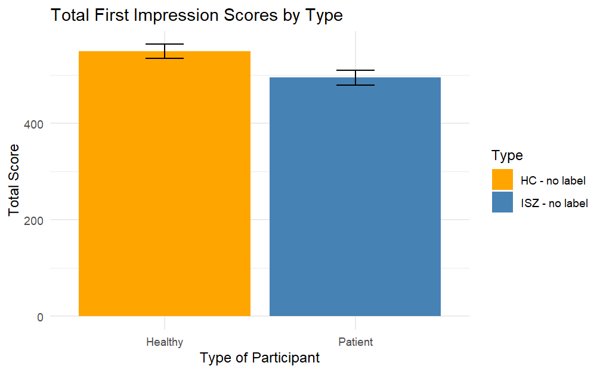

```r
items = c("Sympathique", "Bizarre", "Intelligente", "Appreciable", "Confiance",
           "Dominante", "Conversation", "Temps", "Voisin", "Assis")

result_1st_imp = result_1st_imp %>%
  mutate(
    Bizarre_inversed = 102 - Bizarre,
    Total_score = Sympathique + Bizarre_inversed + Intelligente + Appreciable +
                  Confiance + Dominante + Conversation + Temps + Voisin + Assis
  )

ggplot(result_1st_imp, aes(x = Type, y = Total_score, fill = Type)) +
  stat_summary(fun = mean, geom = "bar", position = "dodge") +
  stat_summary(fun.data = mean_cl_boot, geom = "errorbar", position = position_dodge(0.9), width = 0.2) +
  theme_minimal() +
  labs(title = "Total First Impression Scores by Type",
       x = "Type of Participant",
       y = "Total Score") +
  scale_fill_manual(
    values = c("Patient" = "steelblue", "Healthy" = "orange"),
    labels = c("Patient" = "ISZ - no label", "Healthy" = "HC - no label")
  )
```

Dataset 2 - Label SCZ

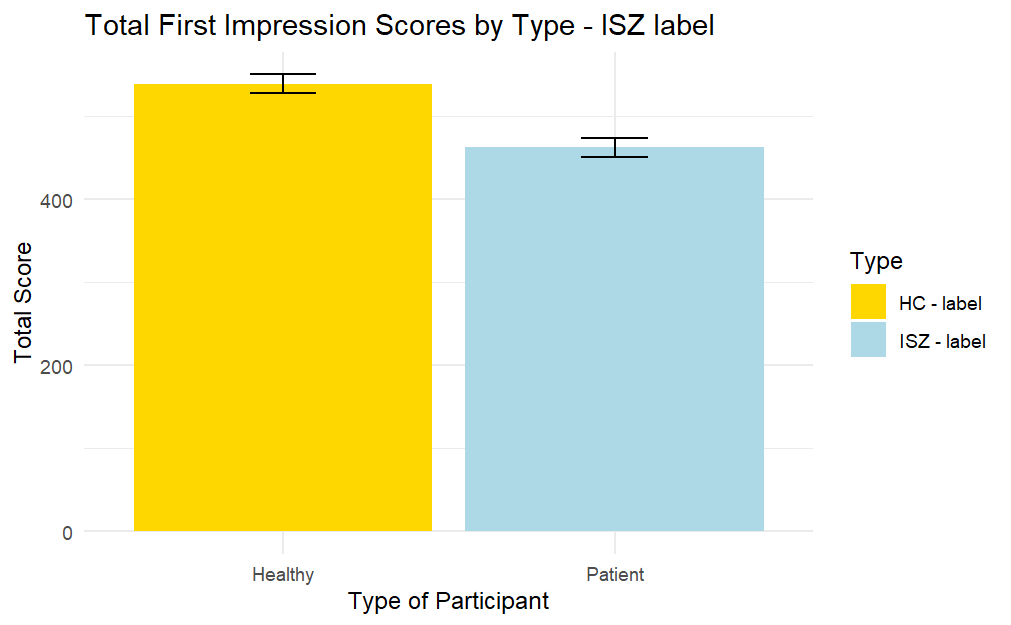

```r
items = c("Sympathique", "Bizarre", "Intelligente", "Appreciable", "Confiance",
           "Dominante", "Conversation", "Temps", "Voisin", "Assis")

result_1st_imp_2 = result_1st_imp_2 %>%
  mutate(
    Bizarre_inversed = 102 - Bizarre,
    Total_score = Sympathique + Bizarre_inversed + Intelligente + Appreciable +
                  Confiance + Dominante + Conversation + Temps + Voisin + Assis
  )

ggplot(result_1st_imp_2, aes(x = Type, y = Total_score, fill = Type)) +
  stat_summary(fun = mean, geom = "bar", position = "dodge") +
  stat_summary(fun.data = mean_cl_boot, geom = "errorbar", position = position_dodge(0.9), width = 0.2) +
  theme_minimal() +
  labs(title = "Total First Impression Scores by Type - ISZ label",
       x = "Type of Participant",
       y = "Total Score") +
  scale_fill_manual(
    values = c("Patient" = "lightblue", "Healthy" = "gold"),
    labels = c("Patient" = "ISZ - label", "Healthy" = "HC - label")
  )
```

Dataset 3 - Label ASD instead of SCZ

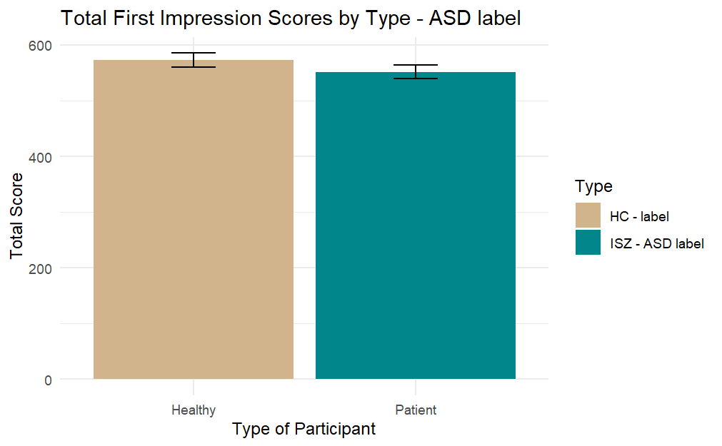

```r
items = c("Sympathique", "Bizarre", "Intelligente", "Appreciable", "Confiance",
           "Dominante", "Conversation", "Temps", "Voisin", "Assis")

result_1st_imp_3 = result_1st_imp_3 %>%
  mutate(
    Bizarre_inversed = 102 - Bizarre,
    Total_score = Sympathique + Bizarre_inversed + Intelligente + Appreciable +
                  Confiance + Dominante + Conversation + Temps + Voisin + Assis
  )

ggplot(result_1st_imp_3, aes(x = Type, y = Total_score, fill = Type)) +
  stat_summary(fun = mean, geom = "bar", position = "dodge") +
  stat_summary(fun.data = mean_cl_boot, geom = "errorbar", position = position_dodge(0.9), width = 0.2) +
  theme_minimal() +
  labs(title = "Total First Impression Scores by Type - ASD label",
       x = "Type of Participant",
       y = "Total Score") +
  scale_fill_manual(
    values = c("Patient" = "turquoise4", "Healthy" = "tan"),
    labels = c("Patient" = "ISZ - ASD label", "Healthy" = "HC - label")
  )
```

Every dataset combined

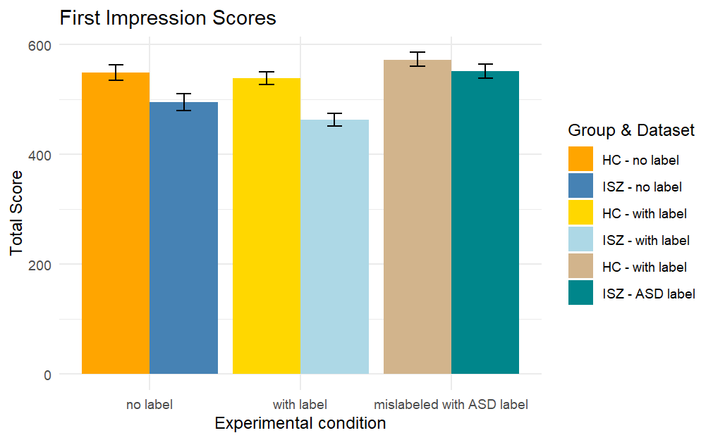

```r
result_1st_imp$Dataset = "Dataset_1"
result_1st_imp_2$Dataset = "Dataset_2"
result_1st_imp_3$Dataset = "Dataset_3"
combined_results = bind_rows(result_1st_imp, result_1st_imp_2, result_1st_imp_3)

combined_results$Interaction_Factor = factor(
  interaction(combined_results$Type, combined_results$Dataset),
  levels = c(
    "Healthy.Dataset_1", "Patient.Dataset_1",
    "Healthy.Dataset_2", "Patient.Dataset_2",
    "Healthy.Dataset_3", "Patient.Dataset_3"
  )
)

full_plot = ggplot(combined_results, aes(x = Dataset, y = Total_score, fill = Interaction_Factor)) +
  stat_summary(fun = mean, geom = "bar", position = position_dodge(width = 0.9)) +
  stat_summary(fun.data = mean_cl_boot, geom = "errorbar", position = position_dodge(width = 0.9), width = 0.2) +
  theme_minimal() +
  labs(
    title = "First Impression Scores",
    x = "Experimental condition",
    y = "Total Score"
  ) +
  scale_fill_manual(
    values = c(
      "Healthy.Dataset_1" = "orange",
      "Patient.Dataset_1" = "steelblue",
      "Healthy.Dataset_2" = "gold",
      "Patient.Dataset_2" = "lightblue",
      "Healthy.Dataset_3" = "tan",
      "Patient.Dataset_3" = "turquoise4"
    ),
    labels = c(
      "Healthy.Dataset_1" = "HC - no label",
      "Patient.Dataset_1" = "ISZ - no label",
      "Healthy.Dataset_2" = "HC - with label",
      "Patient.Dataset_2" = "ISZ - with label",
      "Healthy.Dataset_3" = "HC - with label",
      "Patient.Dataset_3" = "ISZ - ASD label"
    ),
    name = "Group & Dataset"
  ) +
  scale_x_discrete(
    labels = c("Dataset_1" = "no label", "Dataset_2" = "with label", "Dataset_3" = "mislabeled with ASD label")
  )

full_plot
```

#### 5.2.2 Inferential statistics

```r
model = lmerTest::lmer(Total_score ~ interaction(Type, Dataset) + (1|CASE), data = combined_results)
summary(model)
```

```
Linear mixed model fit by REML. t-tests use Satterthwaite's method [
lmerModLmerTest]
Formula: Total_score ~ interaction(Type, Dataset) + (1 | CASE)
   Data: combined_results

REML criterion at convergence: 38084.9

Scaled residuals:
    Min      1Q  Median      3Q     Max
-3.6397 -0.5947  0.0287  0.6000  3.3449

Random effects:
 Groups   Name        Variance Std.Dev.
 CASE     (Intercept)  5950     77.13
 Residual             16710    129.27
Number of obs: 2999, groups:  CASE, 300

Fixed effects:
                                            Estimate Std. Error       df
(Intercept)                                  549.430      9.639  439.191
interaction(Type, Dataset)Patient.Dataset_1  -54.786      8.176 2696.043
interaction(Type, Dataset)Healthy.Dataset_2  -10.558     13.635  439.514
interaction(Type, Dataset)Patient.Dataset_2  -86.874     13.632  439.191
interaction(Type, Dataset)Healthy.Dataset_3   22.860     13.632  439.191
interaction(Type, Dataset)Patient.Dataset_3    1.910     13.632  439.191
                                            t value Pr(>|t|)
(Intercept)                                  56.998  < 2e-16 ***
interaction(Type, Dataset)Patient.Dataset_1  -6.701 2.51e-11 ***
interaction(Type, Dataset)Healthy.Dataset_2  -0.774   0.4391
interaction(Type, Dataset)Patient.Dataset_2  -6.373 4.70e-10 ***
interaction(Type, Dataset)Healthy.Dataset_3   1.677   0.0943 .
interaction(Type, Dataset)Patient.Dataset_3   0.140   0.8886
---
Signif. codes:  0 ‘***’ 0.001 ‘**’ 0.01 ‘*’ 0.05 ‘.’ 0.1 ‘ ’ 1

Correlation of Fixed Effects:
            (Intr) i(T,D)P.D_1 i(T,D)H.D_2 i(T,D)P.D_2 i(T,D)H.D_3
i(T,D)P.D_1 -0.424
i(T,D)H.D_2 -0.707  0.300
i(T,D)P.D_2 -0.707  0.300       0.820
i(T,D)H.D_3 -0.707  0.300       0.500       0.500
i(T,D)P.D_3 -0.707  0.300       0.500       0.500       0.820
```

```r
emmeans_result = emmeans(model, ~ interaction(Type, Dataset), adjust = "Tukey", CIs = TRUE,
                          pbkrtest.limit = 4800, lmerTest.limit = 4800, lmer.df = "satterthwaite")
summary(emmeans_result)
```

```
Note: adjust = "tukey" was changed to "sidak"
because "tukey" is only appropriate for one set of pairwise comparisons
```

```
 Type    Dataset   emmean   SE  df lower.CL upper.CL
 Healthy Dataset_1    549 9.64 439      524      575
 Patient Dataset_1    495 9.64 439      469      520
 Healthy Dataset_2    539 9.64 440      513      564
 Patient Dataset_2    463 9.64 439      437      488
 Healthy Dataset_3    572 9.64 439      547      598
 Patient Dataset_3    551 9.64 439      526      577

Degrees-of-freedom method: satterthwaite
Confidence level used: 0.95
Conf-level adjustment: sidak method for 6 estimates
```

```r
post_hoc_comparisons = pairs(emmeans_result)
summary(post_hoc_comparisons)
```

```
 contrast                              estimate    SE   df t.ratio
 Healthy Dataset_1 - Patient Dataset_1    54.79  8.18 2696   6.701
 Healthy Dataset_1 - Healthy Dataset_2    10.56 13.63  440   0.774
 Healthy Dataset_1 - Patient Dataset_2    86.87 13.63  439   6.373
 Healthy Dataset_1 - Healthy Dataset_3   -22.86 13.63  439  -1.677
 Healthy Dataset_1 - Patient Dataset_3    -1.91 13.63  439  -0.140
 Patient Dataset_1 - Healthy Dataset_2   -44.23 13.63  440  -3.244
 Patient Dataset_1 - Patient Dataset_2    32.09 13.63  439   2.354
 Patient Dataset_1 - Healthy Dataset_3   -77.65 13.63  439  -5.696
 Patient Dataset_1 - Patient Dataset_3   -56.70 13.63  439  -4.159
 Healthy Dataset_2 - Patient Dataset_2    76.32  8.18 2696   9.330
 Healthy Dataset_2 - Healthy Dataset_3   -33.42 13.63  440  -2.451
 Healthy Dataset_2 - Patient Dataset_3   -12.47 13.63  440  -0.914
 Patient Dataset_2 - Healthy Dataset_3  -109.73 13.63  439  -8.050
 Patient Dataset_2 - Patient Dataset_3   -88.78 13.63  439  -6.513
 Healthy Dataset_3 - Patient Dataset_3    20.95  8.18 2696   2.563
 p.value
  <.0001
  0.9717
  <.0001
  0.5478
  1.0000
  0.0159
  0.1751
  <.0001
  0.0005
  <.0001
  0.1414
  0.9427
  <.0001
  <.0001
  0.1070

Degrees-of-freedom method: satterthwaite
P value adjustment: tukey method for comparing a family of 6 estimates
```

```r
ci_post_hoc = confint(post_hoc_comparisons)

model_df = as.data.frame(post_hoc_comparisons)
ci_df = as.data.frame(ci_post_hoc)

model_df$CI_lower = ci_df$lower.CL
model_df$CI_upper = ci_df$upper.CL

sigma_residual = car::sigmaHat(model)

model_df$d = model_df$estimate / sigma_residual

model_df$Contrast = paste(model_df$contrast)
final_results = model_df[, c("Contrast", "estimate", "p.value", "CI_lower", "CI_upper", "d")]

print(final_results)
```

|  | Contrast | estimate | p.value | CI_lower | CI_upper | d |
| --- | --- | --- | --- | --- | --- | --- |
| 1 | Healthy Dataset_1 - Patient Dataset_1 | 54.78600 | 0.000000e+00 | 31.471212 | 78.100788 | 0.42381971 |
| 2 | Healthy Dataset_1 - Healthy Dataset_2 | 10.55819 | 9.717208e-01 | -28.469319 | 49.585706 | 0.08167726 |
| 3 | Healthy Dataset_1 - Patient Dataset_2 | 86.87400 | 7.016041e-09 | 47.853981 | 125.894019 | 0.67204967 |
| 4 | Healthy Dataset_1 - Healthy Dataset_3 | -22.86000 | 5.478380e-01 | -61.880019 | 16.160019 | -0.17684296 |
| 5 | Healthy Dataset_1 - Patient Dataset_3 | -1.91000 | 9.999925e-01 | -40.930019 | 37.110019 | -0.01477559 |
| 6 | Patient Dataset_1 - Healthy Dataset_2 | -44.22781 | 1.594728e-02 | -83.255319 | -5.200294 | -0.34214245 |
| 7 | Patient Dataset_1 - Patient Dataset_2 | 32.08800 | 1.751494e-01 | -6.932019 | 71.108019 | 0.24822996 |
| 8 | Patient Dataset_1 - Healthy Dataset_3 | -77.64600 | 3.361504e-07 | -116.666019 | -38.625981 | -0.60066267 |
| 9 | Patient Dataset_1 - Patient Dataset_3 | -56.69600 | 5.470259e-04 | -95.716019 | -17.675981 | -0.43859530 |
| 10 | Healthy Dataset_2 - Patient Dataset_2 | 76.31581 | 0.000000e+00 | 52.988362 | 99.643251 | 0.59037241 |

[output cut: 5 more lines]

## 6. Correlations

### 6.1 Movements

```r
result_1st_imp$source = "result_1st_imp"
result_1st_imp_2$source = "result_1st_imp_2"
combined_result = rbind(result_1st_imp, result_1st_imp_2)
```

```r
correlation_data = combined_result %>%
  dplyr::select(
    Total_score,
    stimuli_expressivity,
  )

au_columns = c("stimuli_AU01_r", "stimuli_AU02_r", "stimuli_AU04_r", "stimuli_AU05_r",
               "stimuli_AU06_r", "stimuli_AU07_r", "stimuli_AU09_r", "stimuli_AU10_r",
               "stimuli_AU12_r", "stimuli_AU14_r", "stimuli_AU15_r", "stimuli_AU17_r",
               "stimuli_AU20_r", "stimuli_AU23_r", "stimuli_AU25_r", "stimuli_AU26_r",
               "stimuli_AU45_r")

correlation_data = combined_result %>%
  dplyr::select(Total_score, all_of(au_columns))

correlation_with_pvalue = function(x, y) {
  test = cor.test(x, y, method = "pearson")
  return(c(correlation = test$estimate, p_value = test$p.value))
}

results_movements = list()
for (col in colnames(correlation_data)[-1]) {
  result = correlation_with_pvalue(correlation_data$Total_score, correlation_data[[col]])
  if (result[2] < 0.05) {
    results_movements[[col]] = list(correlation = result[1], p_value = result[2])
  }
}

cat("Corrélations significatives avec Total_score:\n")
```

```
Corrélations significatives avec Total_score:
```

```r
for (item in names(results_movements)) {
  cat(paste(item, ":", "corrélation =", results_movements[[item]]$correlation,
            ", p-value =", results_movements[[item]]$p_value, "\n"))
}
```

```
stimuli_AU05_r : corrélation = 0.065405819289373 , p-value = 0.00343782051496627
stimuli_AU12_r : corrélation = 0.0964422937215669 , p-value = 1.56506129705584e-05
stimuli_AU23_r : corrélation = 0.0732801464384558 , p-value = 0.00104276161981
stimuli_AU25_r : corrélation = 0.119466294754398 , p-value = 8.45149572816629e-08
stimuli_AU26_r : corrélation = 0.11729000477619 , p-value = 1.44890161096873e-07
stimuli_AU45_r : corrélation = -0.0520933136451805 , p-value = 0.0198470956034766
```

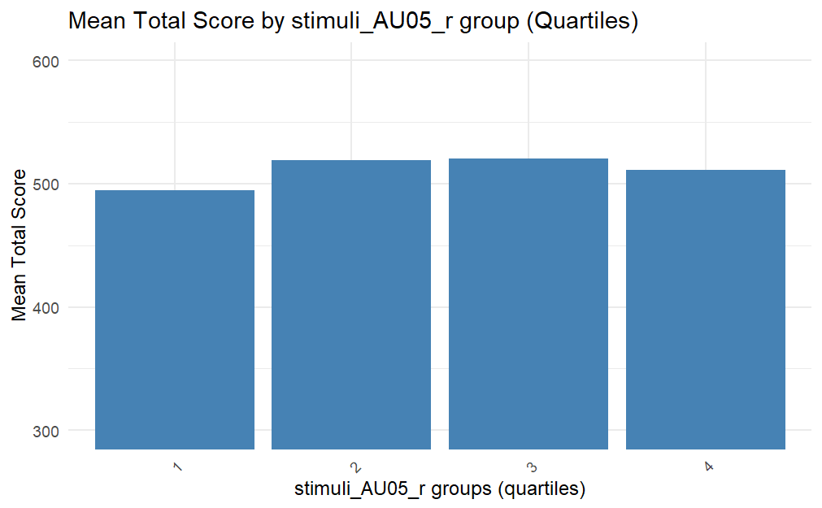

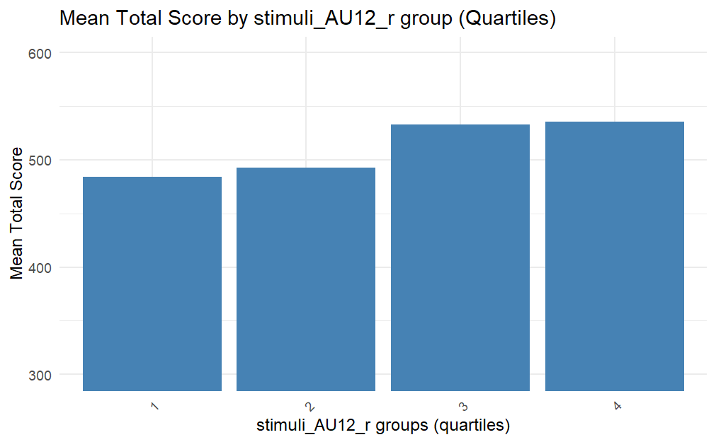

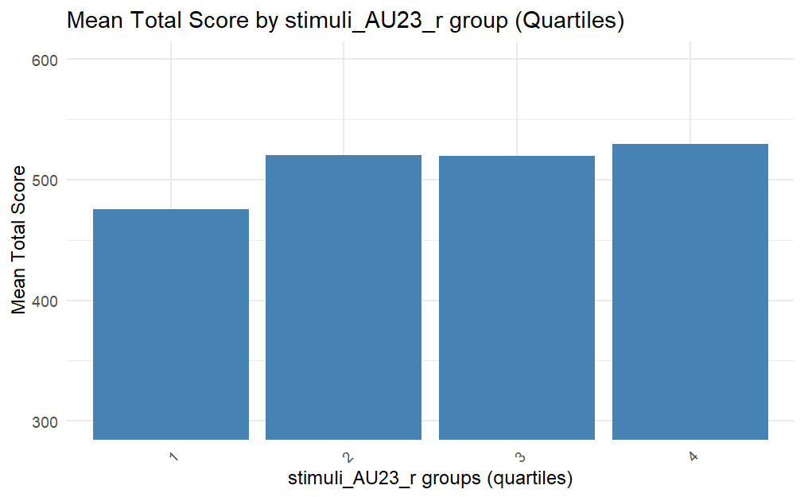

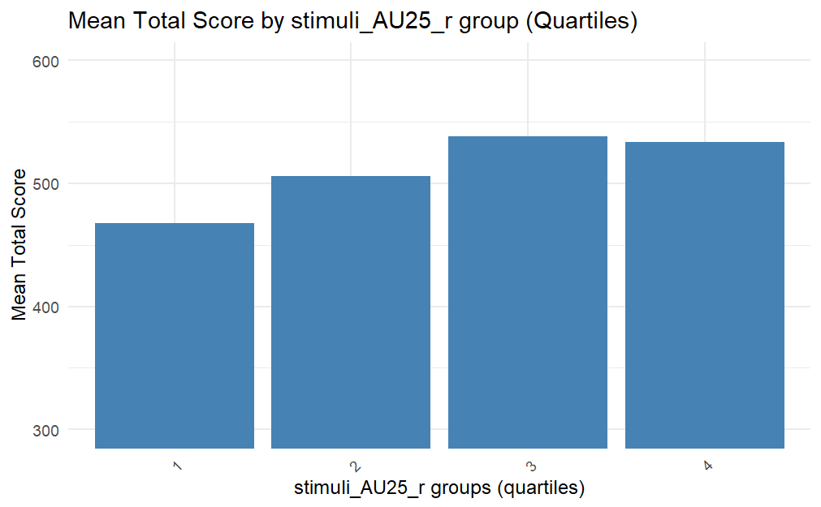

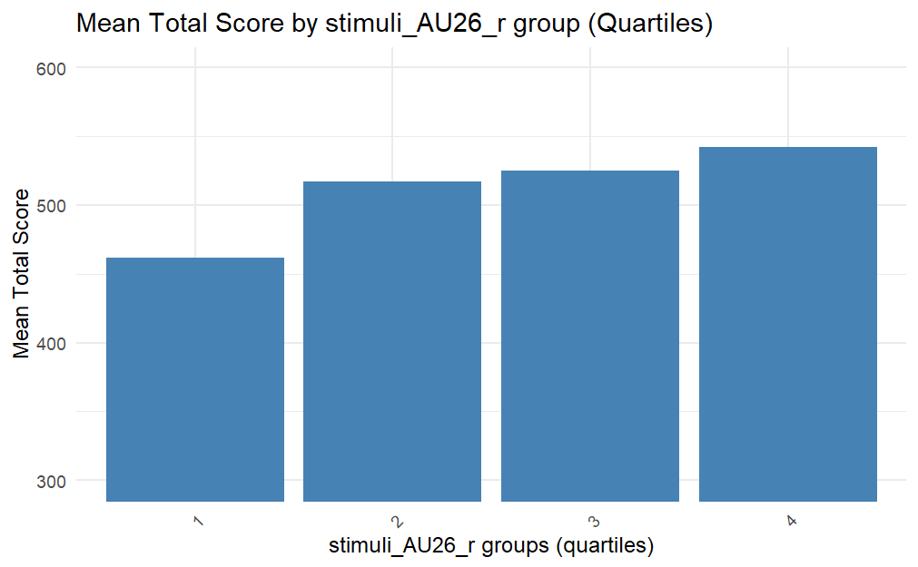

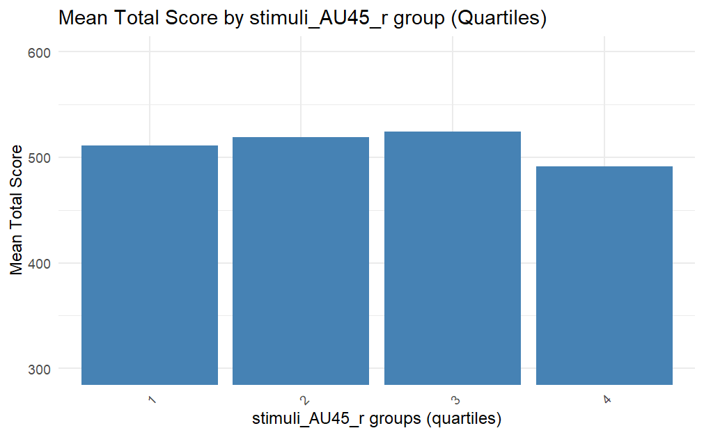

```r
# Quartile
for (item in names(results_movements)) {
  plot_data = correlation_data %>%
    dplyr::select(Total_score, all_of(item)) %>%
    rename(variable_score = all_of(item)) %>%
    mutate(variable_group = ntile(variable_score, 4)) %>%
    group_by(variable_group) %>%
    summarize(mean_total_score = mean(Total_score, na.rm = TRUE), .groups = "drop")

  plot = ggplot(plot_data, aes(x = factor(variable_group), y = mean_total_score)) +
    geom_bar(stat = "identity", fill = "steelblue") +
    labs(
      title = paste("Mean Total Score by", item, "group (Quartiles)"),
      x = paste(item, "groups (quartiles)"),
      y = "Mean Total Score"
    ) +
    theme_minimal() +
    theme(axis.text.x = element_text(angle = 45, hjust = 1)) +
    coord_cartesian(ylim = c(300, 600))
  print(plot)
}
```

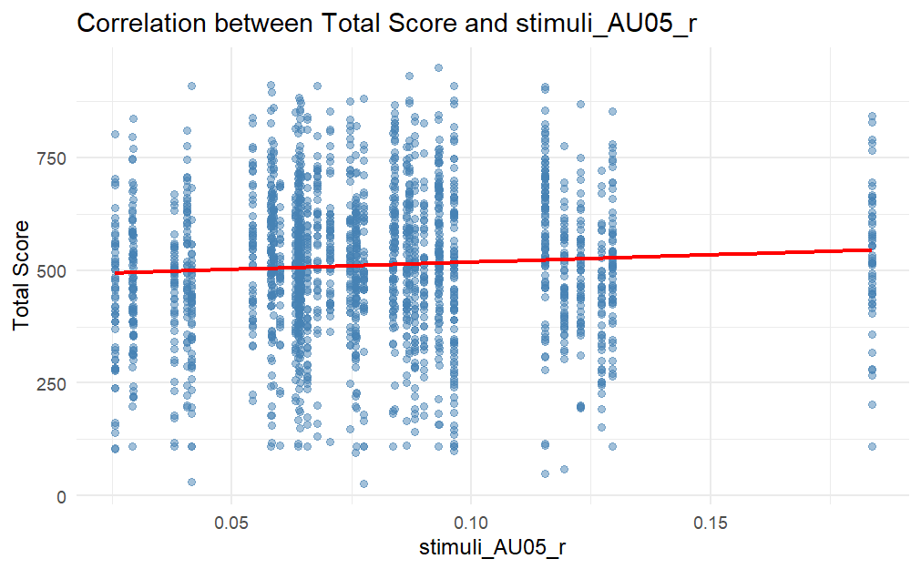

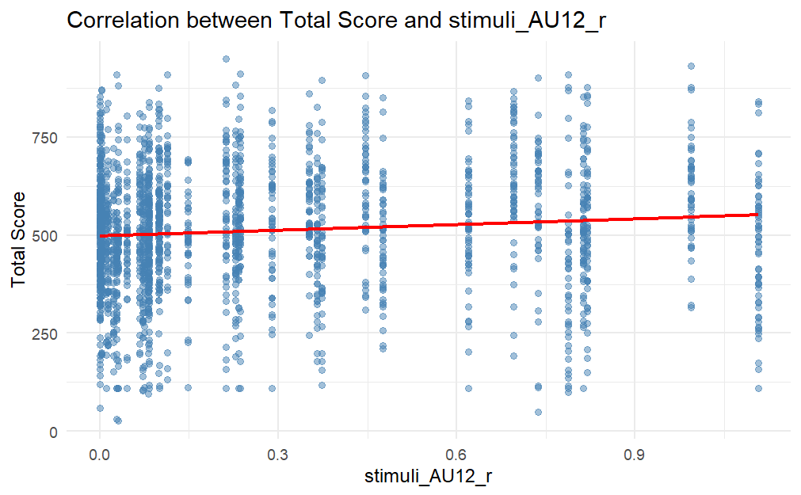

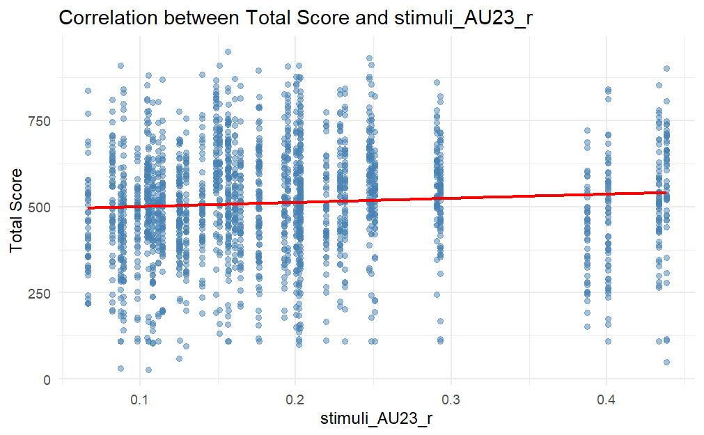

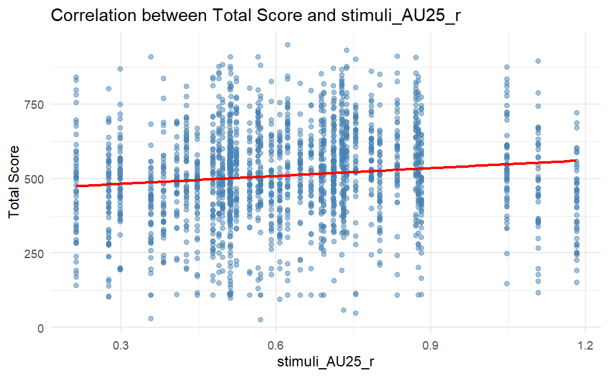

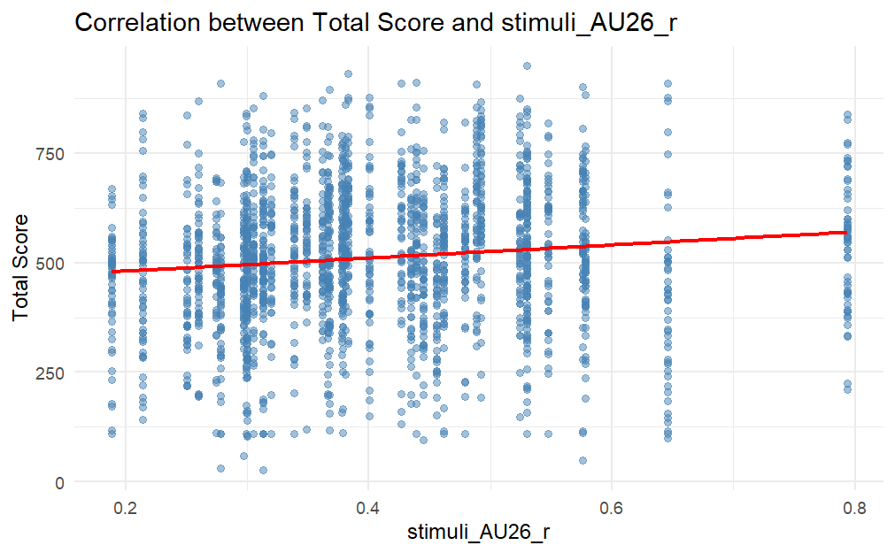

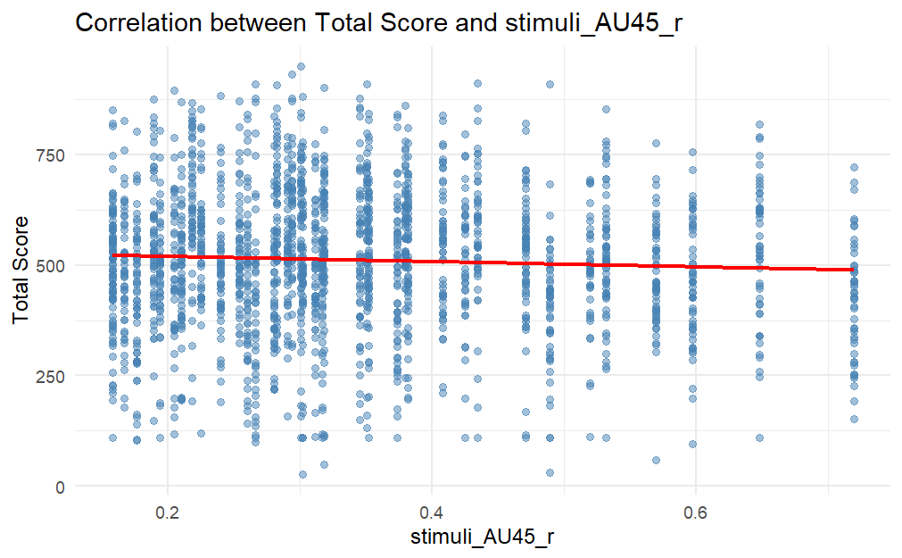

```r
# plot
for (item in names(results_movements)) {
  plot_data = correlation_data %>%
    dplyr::select(Total_score, all_of(item)) %>%
    rename(variable_score = all_of(item))

  plot = ggplot(plot_data, aes(x = variable_score, y = Total_score)) +
    geom_point(alpha = 0.5, color = "steelblue") +
    geom_smooth(method = "lm", color = "red", se = FALSE) +
    labs(
      title = paste("Correlation between Total Score and", item),
      x = item,
      y = "Total Score"
    ) +
    theme_minimal()

  print(plot)
}
```

### 6.2 Patients symptoms

Correlations

```r
patient_data = combined_result %>%
  dplyr::filter(Type == "Patient") %>%
  dplyr::select(
    Total_score,
    stimuli_age,
    stimuli_diagnostic,
    stimuli_PANSS_tot,
    stimuli_PANSS_pos,
    stimuli_PANSS_neg,
    stimuli_PANSS_gen,
    stimuli_med
  )

correlation_with_pvalue = function(x, y) {
  test = cor.test(x, y, method = "pearson")
  return(list(correlation = test$estimate, p_value = test$p.value))  # Retourne une liste
}

results_total_score = list()
results_other_items = list()

for (col in colnames(patient_data)[-1]) {
  result = correlation_with_pvalue(patient_data$Total_score, patient_data[[col]])
  if (result[2] < 0.05) {
    results_total_score[[col]] = list(correlation = result[1], p_value = result[2])
  }
}

cat("Corrélations significatives avec Total_score:\n")
```

```
Corrélations significatives avec Total_score:
```

```r
for (item in names(results_total_score)) {
  cat(paste(item, ":", "corrélation =", results_total_score[[item]]$correlation,
            ", p-value =", results_total_score[[item]]$p_value, "\n"))
}
```

```
stimuli_PANSS_neg : corrélation = c(cor = -0.0671971738940062) , p-value = 0.0336112058842958
stimuli_med : corrélation = c(cor = -0.0900052731590265) , p-value = 0.00439341689436938
```

Plot

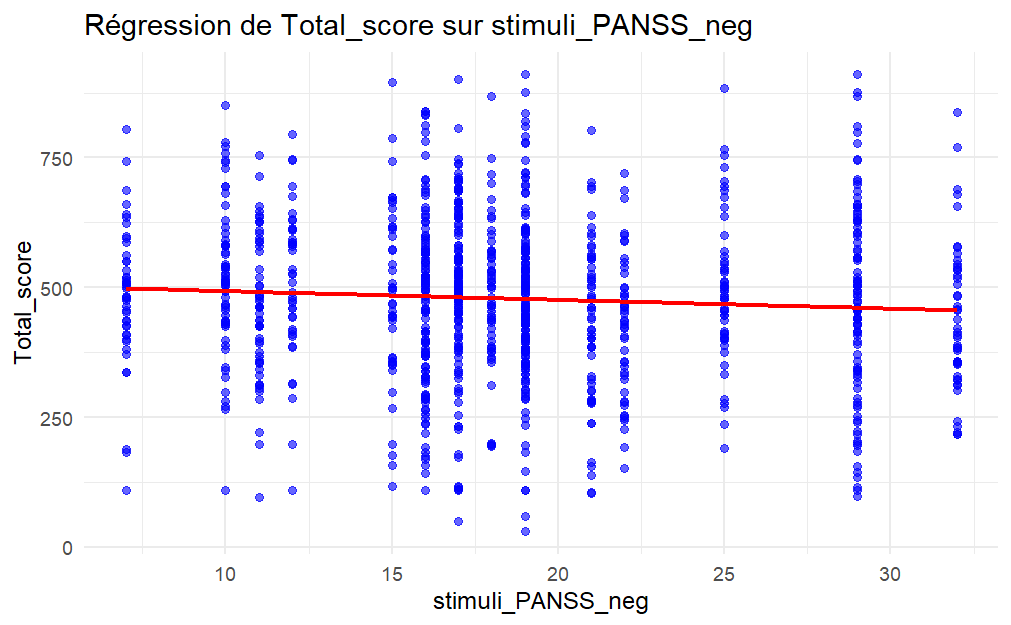

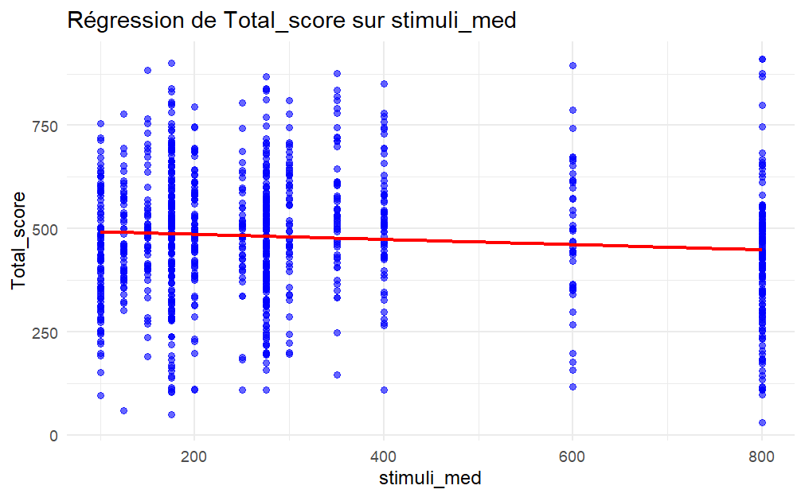

```r
if (length(results_total_score) > 0) {
  for (variable in names(results_total_score)) {
    p = ggplot(patient_data, aes_string(x = variable, y = "Total_score")) +
      geom_point(color = "blue", alpha = 0.6) +
      geom_smooth(method = "lm", color = "red", se = FALSE) +
      labs(title = paste("Régression de Total_score sur", variable),
           x = variable,
           y = "Total_score") +
      theme_minimal()

    print(p)
  }
} else {
  cat("Aucune variable n'est significativement corrélée avec Total_score.\n")
}
```

With AU12, AU25, AU26

```r
significant_vars = list()

for (col in colnames(patient_data)[-1]) {
  result = correlation_with_pvalue(patient_data$Total_score, patient_data[[col]])
  if (result$p_value < 0.05) {
    significant_vars[[col]] = result
  }
}

cat("Variables significativement corrélées avec Total_score:\n")
```

```
Variables significativement corrélées avec Total_score:
```

```r
for (item in names(significant_vars)) {
  cat(paste(item, ":", "corrélation =", significant_vars[[item]]$correlation,
            ", p-value =", significant_vars[[item]]$p_value, "\n"))
}
```

```
stimuli_PANSS_neg : corrélation = -0.0671971738940062 , p-value = 0.0336112058842958
stimuli_med : corrélation = -0.0900052731590265 , p-value = 0.00439341689436938
```

```r
if (length(significant_vars) > 0) {
  selected_vars = names(significant_vars)
  patient_data_selected <- combined_result %>%
    filter(Type == "Patient") %>%
    select(all_of(selected_vars), stimuli_AU12_r, stimuli_AU25_r, stimuli_AU26_r)
  correlation_matrix = matrix(NA, ncol = length(selected_vars), nrow = length(selected_vars),
                               dimnames = list(selected_vars, selected_vars))

  p_value_matrix <- correlation_matrix
  for (i in selected_vars) {
    for (j in selected_vars) {
      if (i != j) {
        result = correlation_with_pvalue(patient_data_selected[[i]], patient_data_selected[[j]])
        correlation_matrix[i, j] = result$correlation
        p_value_matrix[i, j] = result$p_value
      }
    }
  }

  cat("\nMatrice des corrélations entre les variables significatives:\n")
  print(correlation_matrix)

  cat("\nMatrice des p-values entre les variables significatives:\n")
  print(p_value_matrix)

  au_vars = c("stimuli_AU12_r", "stimuli_AU25_r", "stimuli_AU26_r")
  correlation_results_au = data.frame(Variable = character(), AU = character(),
                                       Correlation = numeric(), P_Value = numeric(),
                                       stringsAsFactors = FALSE)

  for (var in selected_vars) {
    for (au in au_vars) {
      result = correlation_with_pvalue(patient_data_selected[[var]], patient_data_selected[[au]])
      correlation_results_au = rbind(correlation_results_au,
                                      data.frame(Variable = var, AU = au,
                                                 Correlation = result$correlation,
                                                 P_Value = result$p_value))
    }
  }

  cat("\nCorrélations entre les variables significatives et AU12, AU25, AU26:\n")
  print(correlation_results_au)
} else {
  cat("\nAucune variable n'est significativement corrélée avec Total_score.\n")
}
```

```
Matrice des corrélations entre les variables significatives:
                  stimuli_PANSS_neg stimuli_med
stimuli_PANSS_neg                NA   0.1196808
stimuli_med               0.1196808          NA

Matrice des p-values entre les variables significatives:
                  stimuli_PANSS_neg  stimuli_med
stimuli_PANSS_neg                NA 0.0001485089
stimuli_med            0.0001485089           NA

Corrélations entre les variables significatives et AU12, AU25, AU26:
```

|  | Variable | AU | Correlation | P_Value |
| --- | --- | --- | --- | --- |
| cor | stimuli_PANSS_neg | stimuli_AU12_r | -0.14438390 | 4.558383e-06 |
| cor1 | stimuli_PANSS_neg | stimuli_AU25_r | -0.16586116 | 1.327504e-07 |
| cor2 | stimuli_PANSS_neg | stimuli_AU26_r | 0.26844401 | 5.753153e-18 |
| cor3 | stimuli_med | stimuli_AU12_r | 0.18079885 | 8.525562e-09 |
| cor4 | stimuli_med | stimuli_AU25_r | -0.05917117 | 6.142059e-02 |
| cor5 | stimuli_med | stimuli_AU26_r | -0.05310925 | 9.324054e-02 |

```r
au_vars = c("stimuli_AU12_r", "stimuli_AU25_r", "stimuli_AU26_r")

cat("\nGraphes de régression entre les variables significatives et AU12, AU25, AU26:\n")
```

```
Graphes de régression entre les variables significatives et AU12, AU25, AU26:
```